# Monthly pension returns analysis: Velliv June 2012 - April 2024

Martin Hoshi Vognsen

21:52 25 June 2026

# Summary

A comparison of returns from pension plans provided by PFA and Velliv respectively:  
- Velliv medium risk (vmr), June 2012 - April 2024  
- Velliv high risk (vhr), June 2012 - April 2024  
- PFA medium risk (pmr), June 2012 - April 2024  
- PFA high risk (phr), June 2012 - April 2024

The combinations of low and high risk funds for each PFA plan can be found here:  
https://www.pfa.dk/privat/opsparing/aktivsammensaetning/

The Velliv website only provides a list of funds.

The analysis also looks at these mixes of plans:  
- Mix medium risk (mmr), June 2012 - April 2024  
- Mix high risk (mhr), June 2012 - April 2024  
- Mix vmr+phr (vm_ph), June 2012 - April 2024  
- Mix vhr+pmr (mh_pm), June 2012 - April 2024

We observe that  
1. **The four plans are weighted blends of the same two underlying funds.** A principal component analysis gives a first component that explains 97.7% of the variance and loads almost equally on all four plans. Within each provider the high-risk plan is a scalar multiple of the medium-risk plan in log returns (slope 1.26 for Velliv, 1.60 for PFA, intercept near zero, $R^2$ of 0.99 and 0.96). PFA’s product description confirms the structure: Profiles B and D are fixed blends of the same low- and high-risk funds. The first decision within a provider is how much of one factor to hold, not which portfolio.

2. **“Risk” is leverage on that factor.** The high-risk plan amplifies the common factor in both directions, earning a higher average return and drawing down more (worst peak-to-trough $-17\%$ vs $-15\%$ for Velliv, $-16\%$ vs $-12\%$ for PFA). That the high-risk path never dips below the medium-risk path is an artefact of starting at the 2012 low; rebased to the eve of the COVID drawdown it falls below for about nine months. The reward-to-risk ratio is near-constant along the menu, so there is no better blend to find: Velliv is a near-perfect leverage ray, and PFA’s slight curvature is well inside sampling noise.
3. **The data fix the body of the distribution but not its tail.** Location and scale are estimated precisely; the tail index is not, with a 95% interval reaching from below 2 to above 5, so we cannot even settle whether the variance is finite. The left skew is the one tail feature that is established ($\hat\xi\approx0.70$, interval entirely below symmetry). The departure from a Gaussian is real and in the tail: Anderson-Darling rejects both the normal and the symmetric-t in favour of the skewed-t, and the worst observed month would recur about once every 400,000 years under a Gaussian against once every two centuries under the skewed-t.
4. **The simulated wealth distribution is the core result, and the choice of distribution governs it.** Simulated over twenty years, the established skewed-t implies roughly a 30% chance that a Velliv plan finishes below its starting value, against 1% to 2% under a symmetric-t or normal. The wealth distribution is right-skewed and bounded below at zero even though the log-return distribution is left-skewed and unbounded. The benign single-regime sample is more likely to understate than overstate the tail, and a mandatory pension cannot “stay home”, so we take the heavy left skew at face value.

The Findings at the end develop these points.

# Returns data

The returns data for PFA can be seen here:  
https://www.pfa.dk/privat/opsparing/pfa-afkast/

The data for Velliv can be seen here:  
https://www.velliv.dk/opsparing/vaekstpension/vaekstpension-aktiv/afkast

Fit log returns to F-S skew standardized Student-t distribution.  
`m` is the location parameter.  
`s` is the scale parameter.  
`nu` is the estimated shape parameter (degrees of freedom).  
`xi` is the estimated skewness parameter.

The long version of Velliv medium risk data runs from January 2007 to April 2024 (incl).  
For January 2007 to May 2012 no low risk and high risk funds existed. For this period the medium risk data is copied into the other funds.

The short version runs from June 2012 to April 2024.

Velliv returns are including bonus and “DinKapital.  
PFA returns are including”KundeKapital".

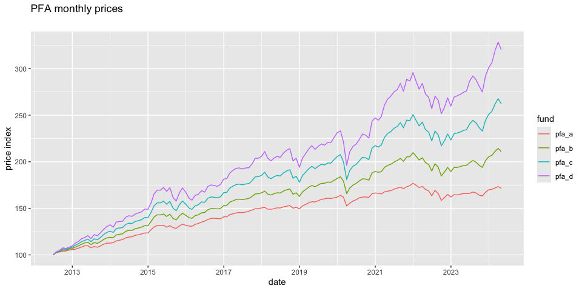

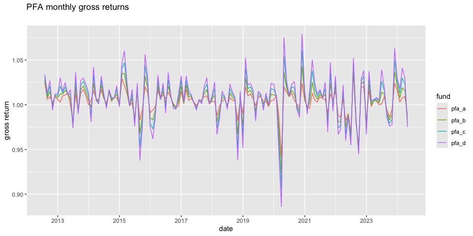

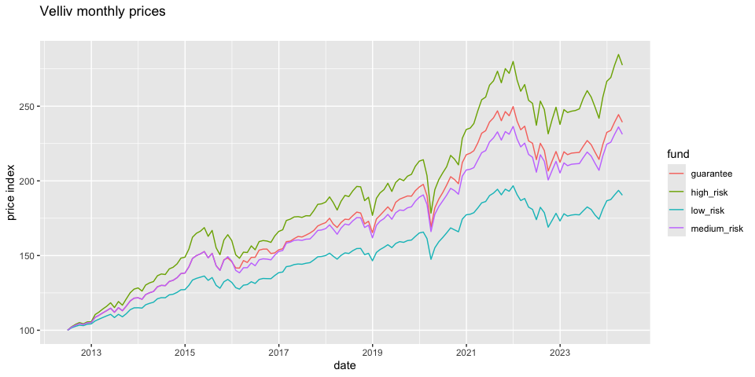

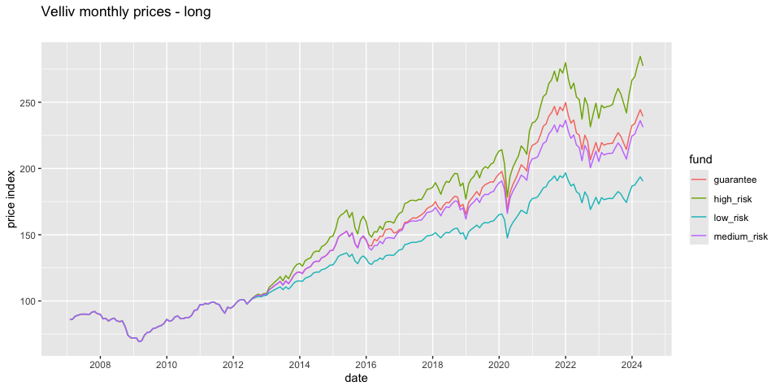

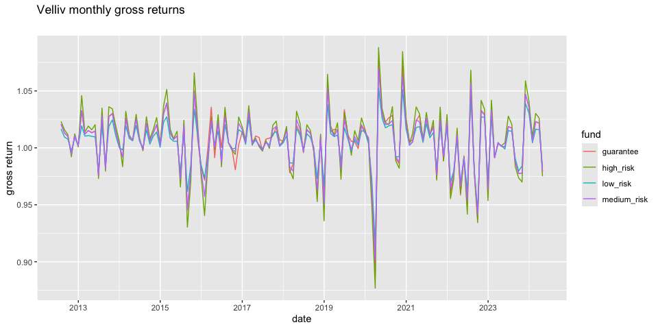

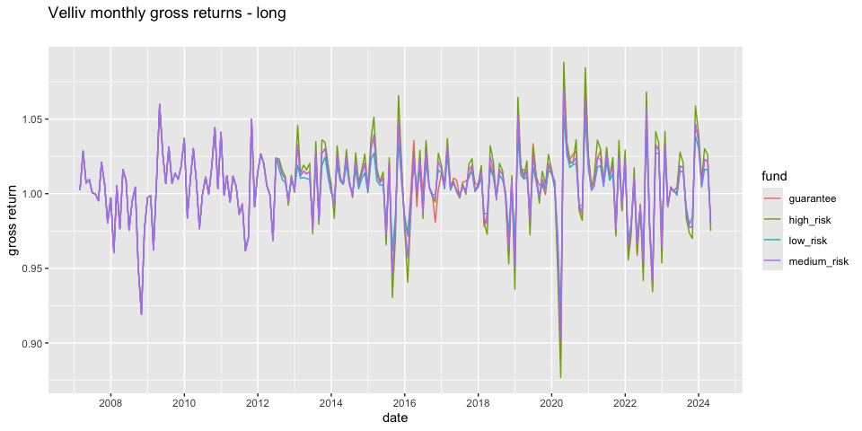

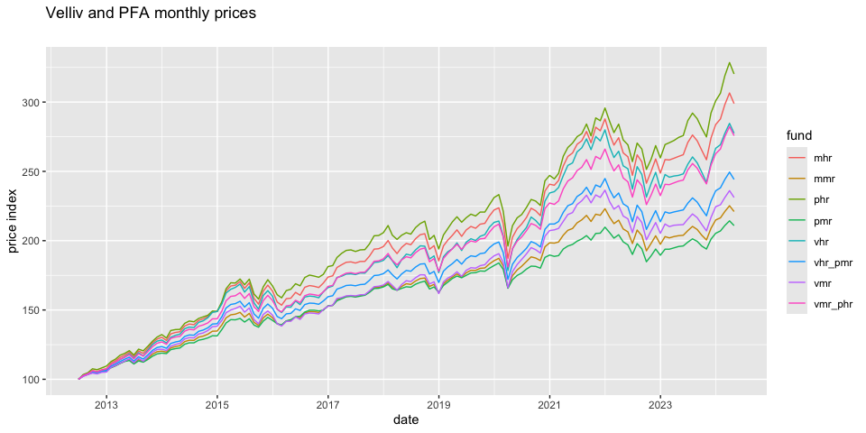

## Summary of log-returns

The summary statistics are transformed back to the scale of gross returns by taking $exp()$ of each summary statistic. (Note: Taking arithmetic mean of gross returns directly is no good. Must be geometric mean.)

|  | vmr | vhr | vmrl | pmr | phr | mmr | mhr | vmr_phr | vhr_pmr |
| --- | --- | --- | --- | --- | --- | --- | --- | --- | --- |
| Min. : | 0.901 | 0.877 | 0.901 | 0.924 | 0.886 | 0.912 | 0.882 | 0.893 | 0.899 |
| 1st Qu.: | 0.996 | 0.994 | 0.995 | 0.999 | 0.994 | 0.997 | 0.995 | 0.996 | 0.996 |
| Median : | 1.010 | 1.012 | 1.007 | 1.008 | 1.012 | 1.009 | 1.013 | 1.011 | 1.011 |
| Mean : | 1.006 | 1.007 | 1.005 | 1.005 | 1.008 | 1.006 | 1.008 | 1.007 | 1.006 |
| 3rd Qu.: | 1.021 | 1.027 | 1.020 | 1.015 | 1.025 | 1.018 | 1.025 | 1.022 | 1.021 |
| Max. : | 1.070 | 1.088 | 1.070 | 1.043 | 1.079 | 1.054 | 1.082 | 1.073 | 1.065 |

## Ranking

| Min. : | ranking | 1st Qu.: | ranking | Median : | ranking | Mean : | ranking | 3rd Qu.: | ranking | Max. : | ranking |
| --- | --- | --- | --- | --- | --- | --- | --- | --- | --- | --- | --- |
| 0.924 | pmr | 0.999 | pmr | 1.013 | mhr | 1.008 | phr | 1.027 | vhr | 1.088 | vhr |
| 0.912 | mmr | 0.997 | mmr | 1.012 | phr | 1.008 | mhr | 1.025 | phr | 1.082 | mhr |
| 0.901 | vmr | 0.996 | vmr | 1.012 | vhr | 1.007 | vhr | 1.025 | mhr | 1.079 | phr |
| 0.901 | vmrl | 0.996 | vhr_pmr | 1.011 | vmr_phr | 1.007 | vmr_phr | 1.022 | vmr_phr | 1.073 | vmr_phr |
| 0.899 | vhr_pmr | 0.996 | vmr_phr | 1.011 | vhr_pmr | 1.006 | vhr_pmr | 1.021 | vmr | 1.070 | vmr |
| 0.893 | vmr_phr | 0.995 | mhr | 1.010 | vmr | 1.006 | vmr | 1.021 | vhr_pmr | 1.070 | vmrl |
| 0.886 | phr | 0.995 | vmrl | 1.009 | mmr | 1.006 | mmr | 1.020 | vmrl | 1.065 | vhr_pmr |
| 0.882 | mhr | 0.994 | phr | 1.008 | pmr | 1.005 | pmr | 1.018 | mmr | 1.054 | mmr |
| 0.877 | vhr | 0.994 | vhr | 1.007 | vmrl | 1.005 | vmrl | 1.015 | pmr | 1.043 | pmr |

## Correlations and covariance

Correlations

|  | vmr | vhr | pmr | phr |
| --- | --- | --- | --- | --- |
| vmr | 1.000 | 0.997 | 0.961 | 0.964 |
| vhr | 0.997 | 1.000 | 0.951 | 0.967 |
| pmr | 0.961 | 0.951 | 1.000 | 0.977 |
| phr | 0.964 | 0.967 | 0.977 | 1.000 |

Covariances

|  | vmr | vhr | pmr | phr |
| --- | --- | --- | --- | --- |
| vmr | 0.001 | 0.001 | 0 | 0.001 |
| vhr | 0.001 | 0.001 | 0 | 0.001 |
| pmr | 0.000 | 0.000 | 0 | 0.000 |
| phr | 0.001 | 0.001 | 0 | 0.001 |

## Path crossing and the starting point

In the “Velliv and PFA monthly prices” plot above every plan starts at index 100 in June 2012, and the riskier plans’ paths never fall below the less-risky ones. It is tempting to read this as *more risk always pays*. It could look like the different risk plans for each provider are simply different weighted shares of returns from a single portfolio. What is actually going on here?

The observation does not generalise: It is an artefact of **where the index starts**. Each high-risk plan is, in effect, a leveraged exposure to one common return factor. The high-risk profile is, to a good approximation, a *scaled* version of the medium-risk one – a slope above 1, essentially zero intercept, and a high $R^2$:

[output not shown]

```
## PFA     corr(medium, high) = 0.977 ;  high = -0.0002 + 1.60 * medium ,  R^2 = 0.955
```

“Approximately” matters: The $R^2$ is below 1, and that residual is where the paths separate. The profiles are not one stream scaled, but blends of two genuinely different funds – a low-risk and a high-risk building block. Backing PFA’s two funds out of the medium and high profiles (high fund $H = D$, low fund $L = 2B - D$, exact for simple returns):

Model each PFA profile as a long-only blend of a low-risk fund $L$ and a high-risk fund $H$, in simple returns: $\text{profile}_X = w_X H + (1-w_X) L$, with $w_X$ the high-risk weight. PFA’s product description gives two weights: profile D is 100% the high-risk fund ($w_D=1$) and profile B is a 50/50 blend ($w_B=0.5$). Then
$$w_D=1 \Rightarrow H=D, \qquad w_B=\tfrac12 \Rightarrow B=\tfrac12H+\tfrac12L \Rightarrow L=2B-D.$$
These are exact identities at the value level, given the two stated weights. They are not estimated. The data only checks that the reconstructed $L$ is coherent, which it is: low volatility, correlation 0.59 with $H$, volatility ratio 3.1.

```
## PFA building blocks (simple returns): corr(low fund, high fund) = 0.59 ; volatility ratio high/low = 3.1
```

The two underlying funds are only moderately correlated and differ several-fold in volatility – far from interchangeable – even though the *profiles* built from them are nearly collinear. That collinearity is not surprising: It is what two equity-dominated portfolios must produce. A “low-risk *plan*” is not a low-risk *fund*. Taking PFA’s published 2026 strategic allocation (this is after a structural change in 2024) as an example, even the low-risk plan is roughly 76% equity-like (global, emerging, private equity, real estate) and only ~24% bonds. To see how little bond content it takes, treat a plan as a weight $w$ in equities and $(1-w)$ in bonds and ask which $w$ reproduces a given correlation with a 100%-equity plan (illustrative capital-market assumptions, not estimated from the data):

| equity vol | bond vol | equity weight for corr 0.986 | equity weight for corr 0.84 |
| --- | --- | --- | --- |
| 15% | 4% | 61% | 29% |
| 12% | 5% | 71% | 39% |
| 18% | 4% | 57% | 26% |

An equity weight of only about two-thirds already yields a ~0.986 correlation with a pure-equity plan. The observed correlations are therefore unremarkable – exactly what equity-heavy “low-risk” plans produce – and not evidence of anything hidden.

The implication for the choice is the point of this section. High correlation means the plans rise and fall together, so over a benign, rising sample the higher-risk plan simply ends up higher and the choice looks free. But correlation describes co-movement, not magnitude and not the tails. The lower-risk plan holds a real bond sleeve and a distinct, lower-volatility fund, and – as the crossings above show – that cushion is exactly what bites in a drawdown. The plans look alike because both are mostly equities; they are not alike when equities fall.

### One common factor

The correlations point to a single common factor. A principal component analysis of the four plans confirms it.

Principal components of the four plans’ monthly log returns (correlation scaling).

|  | variance share | cumulative |
| --- | --- | --- |
| PC1 | 97.7% | 97.7% |
| PC2 | 1.7% | 99.4% |
| PC3 | 0.6% | 100.0% |
| PC4 | 0.0% | 100.0% |

The first component explains 97.7% of the variance and the first two explain 99.4%. The first component loads almost equally on all four plans, near 0.50 each, so it is a common market factor. The second component, under two percent, is a Velliv-versus-PFA contrast. To a close approximation the four plans are therefore one factor seen at four exposures, which is the structure the leverage reading below assumes. The within-provider relation is the special case of this: The high plan is a scaled version of the medium plan, as the regression above shows. PFA’s two profiles are in addition fixed blends of the same two building blocks, with the high-risk fund equal to profile D and the low-risk fund recovered as $2B-D$. That last decomposition rests on PFA’s stated profile weights, not on the data, which only confirm that the recovered low-risk fund is coherent.

### The crossing condition

For each plan $X\in\{m,h\}$ (medium, high) and period $u=1,2,\dots$ from the chosen start date, let $s_{X,u}$ be the simple return (gross return $1+s_{X,u}$), $r_{X,u}=\log(1+s_{X,u})$ the log return, $R_{X,t}=\sum_{u=1}^{t}r_{X,u}$ the cumulative log return through period $t$, and $W_{X,t}=100\,e^{R_{X,t}}$ the wealth index rebased to $100$ at the start. Since $x\mapsto 100\,e^{x}$ is strictly increasing,
$$W_{h,t}<W_{m,t}\iff R_{h,t}<R_{m,t},$$
exactly. What makes this usable is a model for how $R_{h,t}$ relates to $R_{m,t}$.

**Model A (proportionality in log returns).** The regression above fits the affine relation in log returns, $r_{h,u}=\alpha+\beta\,r_{m,u}+\varepsilon_u$ with $\beta>1$. Summing over $u=1,\dots,t$ and writing $E_t=\sum_{u\le t}\varepsilon_u$ for the cumulative residual gives $R_{h,t}=\alpha t+\beta R_{m,t}+E_t$, so
$$\begin{aligned}
W_{h,t}<W_{m,t}
&\iff \alpha t+\beta R_{m,t}+E_t<R_{m,t}\\
&\iff \alpha t+E_t<(1-\beta)\,R_{m,t}\\
&\iff R_{m,t}<-\frac{\alpha t+E_t}{\beta-1},
\end{aligned}$$
the last step dividing by $1-\beta<0$, which reverses the inequality. Writing $\theta_t=-(\alpha t+E_t)/(\beta-1)$ for the threshold, the crossing is $R_{m,t}<\theta_t$. In the idealisation $\alpha=0$ and $\varepsilon_u\equiv0$ (hence $E_t\equiv0$) the threshold is $\theta_t=0$, giving the clean rule
$$W_{h,t}<W_{m,t}\iff R_{m,t}<0\iff W_{m,t}<100:$$
the high plan sits below the medium plan exactly over those windows in which the medium (safer) plan is itself below its starting value.

The clean rule replaces $\theta_t$ by $0$; its error $\theta_t$ has an intercept part $-\alpha t/(\beta-1)$ and a residual part $-E_t/(\beta-1)$. With an intercept in the regression, least squares forces $\sum_{u=1}^{T}\hat\varepsilon_u=0$ over the full sample of length $T$, so $E_T=0$ and the residual part vanishes over the whole window; over a strict sub-window (the COVID rebasing below is one), the partial sum $E_t=\sum_{u\le t}\hat\varepsilon_u$ is generally nonzero and is the slack between the clean rule and the truth there.

More fundamentally, $\beta$ is the population least-squares slope: Minimising $E\!\left[(r_h-a-b\,r_m)^2\right]$ over $(a,b)$ gives the first-order conditions $a=E[r_h]-b\,E[r_m]$ and $E[r_m r_h]=a\,E[r_m]+b\,E[r_m^2]$, which eliminate $a$ to leave $\operatorname{Cov}(r_h,r_m)=b\,\operatorname{Var}(r_m)$, hence
$$\beta=\frac{\operatorname{Cov}(r_h,r_m)}{\operatorname{Var}(r_m)}.$$
This is defined only when the second moments are finite, and stably estimable only under stronger conditions. The fitted $\nu\approx3$ to $4$ with a confidence interval reaching $\nu\le2$, together with the max-sum plots, is precisely the evidence that finite variance cannot be assumed: The crossing rule is therefore not a geometric identity but a statement conditional on the existence of the second moments, the same caveat that governs every tail estimate in this study.

**Model B (constant leverage).** Read “the high plan is a $\beta$-leveraged version of the medium plan” literally, as a position rebalanced each period to hold constant exposure $\beta$. Ignoring financing this scales the simple returns, $s_{h,u}=\beta\,s_{m,u}$ (a per-period borrowing rate $c$ gives $s_{h,u}=\beta s_{m,u}-(\beta-1)c$; take $c=0$). Log returns are now not proportional, and the crossing condition is exact,
$$W_{h,t}<W_{m,t}\iff\sum_{u=1}^{t}\bigl[\log(1+\beta s_{m,u})-\log(1+s_{m,u})\bigr]<0
\iff\prod_{u=1}^{t}\frac{1+\beta s_{m,u}}{1+s_{m,u}}<1,$$
valid while $s_{m,u}>-1/\beta$ (the leveraged plan is not wiped out). Expanding with $\log(1+x)=x-\tfrac12 x^2+O(x^3)$ gives $\log(1+\beta s)-\log(1+s)=(\beta-1)s-\tfrac12(\beta^2-1)s^2+O(s^3)$; summing, setting the total $<0$, dividing by $\beta-1>0$ and using $\beta^2-1=(\beta-1)(\beta+1)$,
$$\bar s_m<\tfrac12(\beta+1)\,\overline{s_m^{2}},\qquad
\overline{s_m^{2}}=\tfrac1n\sum_{u}s_{m,u}^2=\widehat{\operatorname{Var}}(s_m)+\bar s_m^2
\approx\hat\sigma_m^2 .$$
For i.i.d. returns with $\mu=E[s_m]$ and $\sigma^2=\operatorname{Var}(s_m)$, the long-run growth rate is $g=E[\log(1+s)]\approx\mu-\tfrac12\sigma^2$, so $g_m\approx\mu-\tfrac12\sigma^2$ and $g_h\approx\beta\mu-\tfrac12\beta^2\sigma^2$. The leveraged path stays below iff $g_h<g_m$:
$$(\beta-1)\mu<\tfrac12(\beta^2-1)\sigma^2\iff\mu<\tfrac12(\beta+1)\sigma^2\iff\beta>2\beta^\star-1,$$
with the growth-optimal (Kelly) leverage $\beta^\star=\mu/\sigma^2$.

**The two models contrasted.** Both conditions read $\bar s_m<k\,\overline{s_m^{2}}$: $k=\tfrac12$ for Model A (since $R_m<0\iff\sum_u\log(1+s_{m,u})<0\iff\bar s_m<\tfrac12\overline{s_m^2}$ to second order) and $k=\tfrac{\beta+1}{2}$ for Model B. With $\beta>1$ Model B crosses below over a wider set of paths; in drift terms the thresholds on the medium plan’s growth are $g_m<0$ (A) versus $g_m<\tfrac12\beta\sigma^2$ (B). Model B’s is strictly positive (a constant-leverage high plan can sit below while the medium plan still grows), because leverage multiplies the variance by $\beta^2$ but the mean only by $\beta$. The two constructions differ in which variable carries the proportionality:
$$g_h^{A}=E[\beta r_m]=\beta g_m,\qquad
g_h^{B}=\beta\mu-\tfrac12\beta^2\sigma^2=\beta g_m-\underbrace{\tfrac12\beta(\beta-1)\sigma^2}_{\text{leverage drag}} .$$
Model A imposes $r_h=\beta r_m$, i.e. $1+s_h=(1+s_m)^{\beta}$, a convex power rule ($s_h=\beta s_m+\tfrac12\beta(\beta-1)s_m^2+O(s^3)$, holding more than $\beta s_m$ in large moves), and that extra convexity has expectation $\tfrac12\beta(\beta-1)\sigma^2$, exactly cancelling the drag, so $g_h^{A}=\beta g_m$ with no separate penalty.

For the four plans, the high plan regressed on the medium plan (monthly log returns):

High plan regressed on medium plan, monthly log returns (n = 142).

|  | $\beta$ | $\alpha$ (per month) | $R^2$ (log) | $R^2$ (simple) |
| --- | --- | --- | --- | --- |
| Velliv (medium to high) | 1.263 | -0.0003 | 0.994 | 0.993 |
| PFA (medium to high) | 1.600 | -0.0002 | 0.955 | 0.954 |

Medium-plan moments and leverage diagnostics (annualised).

|  | $\mu$ (ann.) | $\sigma$ (ann.) | $\tfrac12\beta\sigma^2$ | $\tfrac12\beta(\beta-1)\sigma^2$ | Kelly $\beta^\star$ |
| --- | --- | --- | --- | --- | --- |
| Velliv | 7.45% | 8.35% | 0.44% | 0.12% | 10.7 |
| PFA | 6.50% | 5.94% | 0.28% | 0.17% | 18.4 |

$\hat\beta>1$ with $\hat\alpha\approx0$ for both, so Model A’s clean rule is the operative one. The log- and simple-return $R^2$ differ by only about $0.001$ because returns are small, so Models A and B are observationally almost identical here; the distinction is conceptual. The constant-leverage threshold sits only $\tfrac12\beta\hat\sigma^2\approx0.3\%$ to $0.4\%$ per year above zero, because $\beta$ is near $1$; for a genuine 2x or 3x product it would dominate. The in-sample Kelly $\hat\beta^\star\approx11$ to $18$ is not a tangency to chase: it is $\hat\mu/\hat\sigma^2$ measured on a crash-free window, the ratio of the two least-robust quantities: The moment-existence caveat once more.

June 2012 was a low point just before a long bull market, so the safer plans never revisited 100 and the paths never crossed. Start the index instead just before a drawdown and the high-risk path falls below. The COVID crash is a clean realised example: Rebasing every plan to 100 at the end of February 2020, the high-risk plans drop **below** the medium-risk plans through the March-2020 trough – and stay there for about nine months – before recovering.

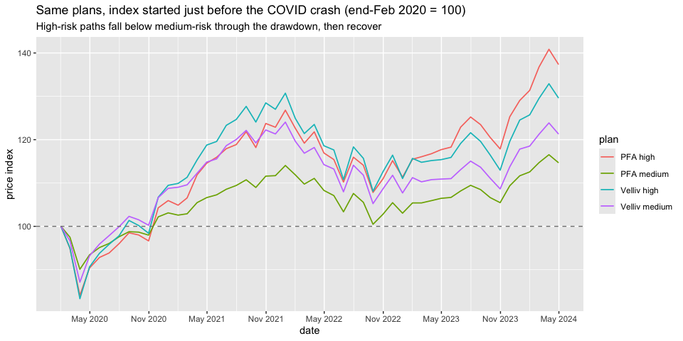

The high-risk plans regain and overtake the medium-risk plans only once the cumulative return since the start date turns positive again. Whether the realised paths cross is therefore not a property of the plans but of the chosen starting point relative to the market cycle. (A deeper or more prolonged regime – e.g. one in which the index spends years below its start, as in 2008-2009 – would keep the high-risk plan below for correspondingly longer.)

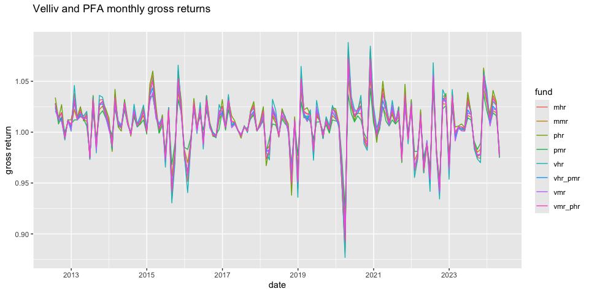

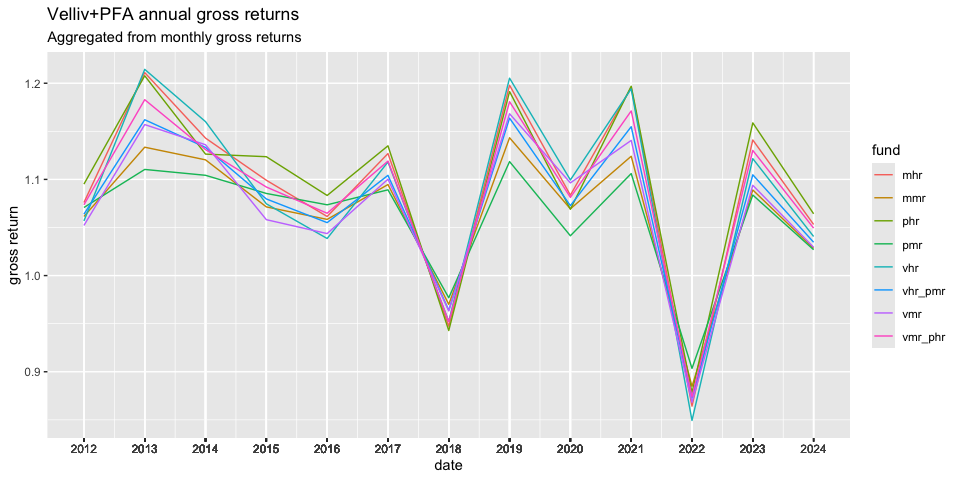

## When the high plan falls behind

Absolute wealth paths are hard to compare near the terminal date. There they converge. The lead of the high plan over the medium plan is easier to read. It is the high index minus the medium index, with both rebased to 100 at the entry. It crosses zero exactly when the high plan falls behind.

Take first a fixed terminal and a varying entry. Invest 100 at every month in the sample. Hold each entry to the last month in the data. The terminal wealth of an entry at month $i$ is $W_i=100\,e^{R_i}$ with $R_i=\sum_{u=i}^{t} r_{X_u}$ and $t$ the last month. The lead is the high terminal wealth minus the medium terminal wealth, read across entry months.

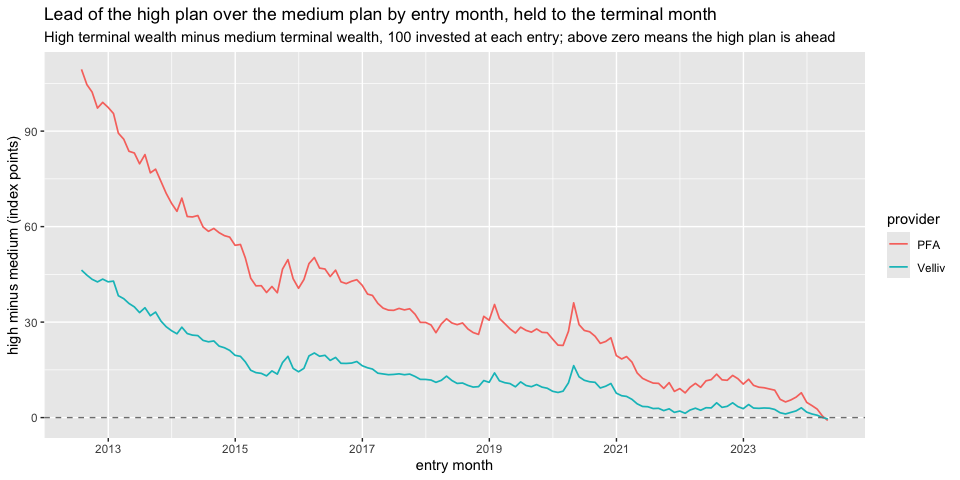

Now reverse the exercise. Fix the entry at the first month and vary the terminal. Invest 100 at the first month. Read the lead at each terminal month over the entire period.

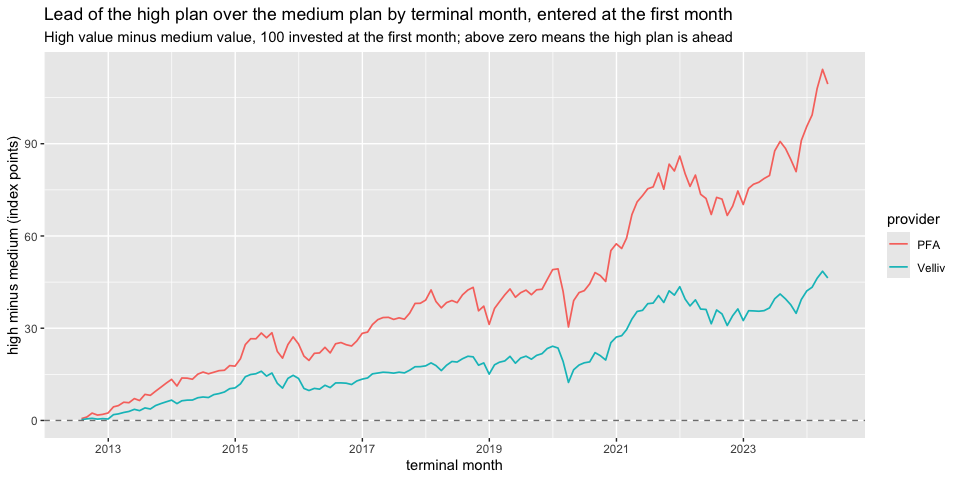

The lead never turns negative. It builds over the bull market. It dips through the March-2020 trough but stays above zero. The two plots are mirror images. The full-sample lead sits at the left edge of the first plot and at the right edge of this one. From the 2012 low looking forward, and from the 2024 high looking back, the high plan stays ahead.

Neither full-sample view shows a below-zero lead. That does not rule one out. Each view fixes one endpoint and moves the other. To be certain the lead never turns negative we would have to run every entry against every terminal, every sub-window of the sample. We do not do that. A below-zero lead appears whenever the entry sits at an interior peak. The plot below is one example. The entry is the eve of the COVID crash, end-February 2020, a market peak.

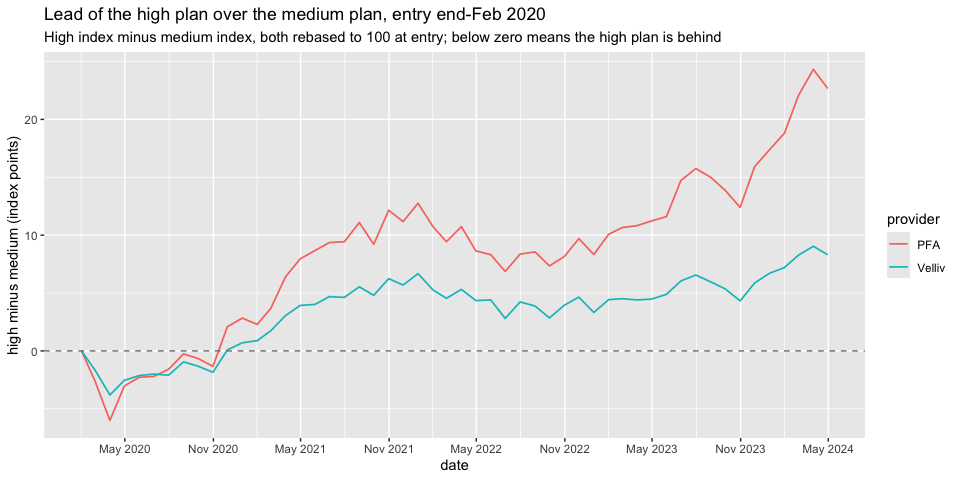

The lead turns negative through the March-2020 trough. It stays negative for about nine months before recovering. This is the realised crossing, now visible as the lead dipping below zero. The condition is the one derived above. The high plan trails the medium plan exactly while the medium plan is below its entry value.

**A counterfactual.** The non-crossing in the two full-sample views is a feature of this sample. The sample is a bull market that ends near its high. To see how much rests on that, reverse every monthly return. Replace each $r_{X_u}$ with $-r_{X_u}$. The counterfactual terminal wealth is $W'_i=100\,e^{R'_i}$ with $R'_i=\sum_{u=i}^{t} -r_{X_u}$. This is the same world with the opposite luck. A rising market becomes a falling one. The leverage relation survives the reversal. The reversed high plan is still a $\beta$-scaled version of the reversed medium plan, because negating both sides of $h_u=\alpha+\beta m_u$ leaves the slope. Only the sign of the cumulative return flips.

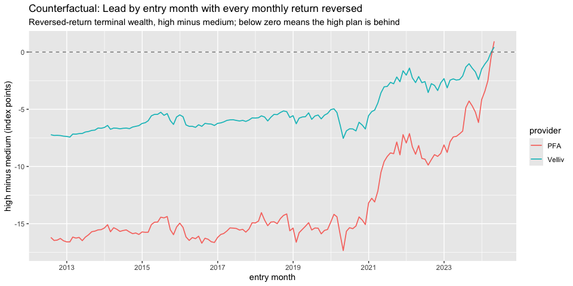

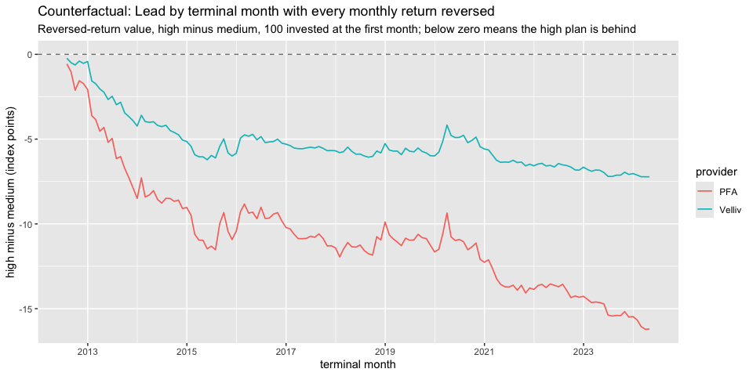

## The downward bound

A pension account cannot fall below zero. In return terms the simple return satisfies $s\ge-1$: At worst a period wipes out the capital, but it cannot take more. This bound sits oddly beside a left-skewed and unbounded distribution of log returns. The two are reconciled by the way wealth compounds. Wealth is $W=100\,e^{R}=100\prod_u(1+s_u)$, and $e^{R}>0$ for every real $R$, so exponentiating a log-return model can never produce a negative value. The simulated paths approach zero but never breach it. The wealth distribution is therefore right-skewed and bounded below at zero, even though the log-return distribution that generates it is left-skewed and unbounded. The heavy left tail in log space becomes a cluster of paths near zero, not a set of negative balances.

This also settles which leverage reading applies. Under log-return scaling, $1+s_h=(1+s_m)^{\beta}$, so as the medium plan approaches a total loss the high plan does too, and neither breaches the bound. Under constant financial leverage, $s_h=\beta s_m$, a loss in the medium plan beyond $1/\beta$ would drive the high plan below $-1$ and wipe it out. The plans never do this, because they are long-only blends: The weights sum to one and no money is borrowed, so the value is a weighted sum of non-negative fund values and stays non-negative. The leverage here is higher exposure to the volatile fund, not borrowed money, which is why the data follow the log-scaling relation rather than constant financial leverage.

## The Sharpe ratio: Leverage ray or curve?

The crossing model $r_{h,u}=\alpha+\beta\,r_{m,u}+\varepsilon_u$ has a second consequence – about reward per unit of risk rather than path order.

**Definition.** The annualised Sharpe ratio of plan $X$ is $S_X=(\mu_X-r_f)/\sigma_X$, with $\mu_X$ and $\sigma_X$ the mean and standard deviation of the monthly log returns and $r_f$ the risk-free rate. Danish short rates are near zero over the sample, so we set $r_f=0$ and $S_X=\mu_X/\sigma_X$, estimated by $\hat S_X=(\bar x_X/\hat\sigma_X)\sqrt{12}$; the $\sqrt{12}$ annualisation assumes serially independent returns. Geometrically, plotting each plan as a point $(\sigma_X,\mu_X)$, the Sharpe is the slope of the line from the origin to that point, so a set of plans shares one Sharpe if and only if the points lie on a single ray through the origin.

**A ray is the signature of leverage.** Under Model A with a clean fit ($\alpha=0$, $\varepsilon_u\equiv0$), scaling the log returns by $\beta$ scales both moments by $\beta$ (so $\mu_h=\beta\mu_m$ and $\sigma_h=\beta\sigma_m$), giving $S_h=\beta\mu_m/(\beta\sigma_m)=S_m$: The two plans share a Sharpe and lie exactly on a ray. This is the same log-scaling that produced the clean crossing rule. With a real fit ($\alpha\approx0$, $R^2<1$), let $\rho=\operatorname{Cov}(r_h,r_m)/(\sigma_h\sigma_m)$ be the correlation; since $\operatorname{Cov}(r_h,r_m)=\beta\sigma_m^2$ we have $\rho=\beta\sigma_m/\sigma_h$, hence
$$S_h=\frac{\alpha+\beta\mu_m}{\sigma_h}=\rho\left(S_m+\frac{\alpha}{\beta\sigma_m}\right)\approx\rho\,S_m\quad(\alpha\approx0).$$
The high plan’s Sharpe is the medium plan’s Sharpe scaled by the correlation $\rho=\sqrt{R^2}$. A perfect leverage ray is $\rho=1$ ($S_h=S_m$); the menu bends by exactly the log-collinearity shortfall $1-\rho$, the same residual the crossing section flagged. (Equivalently, in simple-return space, constant leverage financed at $r_f$, i.e. Model B, traces the constant-excess-Sharpe Capital Allocation Line; a ray is the signature of leverage in either reading.)

**Why the curvature cannot be read off.** Two obstructions, both the study’s theme. First, $S=\mu/\sigma$ requires a finite variance ($\nu>2$); the fitted $\nu$ has a confidence interval reaching $\nu\le2$, so the denominator may not exist, and where it does not the Sharpe is not a population quantity. Second, even granting a finite variance, the sampling variance of the estimator is (Lo 2002; Mertens 2002, under serial independence)
$$\operatorname{Var}(\hat S)\approx\frac1T\left(1+\tfrac12 S^2-\gamma_3 S+\tfrac14(\gamma_4-3)S^2\right),$$
with $\gamma_3$ the skewness and $\gamma_4$ the kurtosis, which is finite only for $\nu>4$. The fitted $\nu\approx3.4$ to $4.3$ straddles $4$: The Sharpe is computable, but its own standard error need not be finite. The figures below use the i.i.d.-normal standard error $\operatorname{SE}(\hat S)\approx\sqrt{12\,(1+S^2/24)/n}$, which is a lower bound: The sample skewness ($\approx-1$) and kurtosis ($\approx6$) inflate it, and the population kurtosis may be infinite.

Annualised Sharpe ratio by plan and start date.

|  | Velliv medium | Velliv high | PFA medium | PFA high |
| --- | --- | --- | --- | --- |
| from 2012-06 (n=142) | 0.84 | 0.81 | 1.06 | 1.01 |
| from 2016-01 (n=100) | 0.61 | 0.58 | 0.75 | 0.75 |
| from 2019-01 (n=64) | 0.66 | 0.66 | 0.67 | 0.82 |

The full-sample decomposition $S_h=\rho(S_m+\alpha/(\beta\sigma_m))$ and the sampling error of each estimate:

Within-provider Sharpe decomposition and sampling error (full sample, n = 142; annualised; SE i.i.d.-normal, a lower bound).

|  | $\rho$ | $S_m$ | $S_h$ | $\rho S_m$ | $\mathrm{SE}(S)$ | gap / SE |
| --- | --- | --- | --- | --- | --- | --- |
| Velliv | 0.997 | 0.84 | 0.81 | 0.84 | 0.29 | 0.11 |
| PFA | 0.977 | 1.06 | 1.01 | 1.03 | 0.30 | 0.17 |

**Reading.** For Velliv $\hat\rho=0.997$: The medium and high plans are a near-perfect leverage ray, $\hat S_h$ is reproduced by $\hat\rho(\hat S_m+\hat\alpha/(\hat\beta\hat\sigma_m))$ to the displayed precision, and the gap $\hat S_m-\hat S_h\approx0.03$ is about $0.1$ of one standard error. Choosing the Velliv risk level is pure risk appetite, with nothing to optimise: The same $\beta$-scaling that gives Velliv’s clean crossing rule. For PFA $\hat\rho=0.977$: The menu is measurably more bent (by about $2\%$), but the Sharpe gap is still only about $0.2$ of a standard error, and which profile leads flips with the start date (the by-window table above). So although PFA’s menu does curve, no best-Sharpe blend is identifiable at this sample size, and the standard error itself is only a lower bound (the kurtosis it omits may be infinite). It is not worth paying, in added risk or in fees, to chase a tangency that the data cannot locate.

The risk-return map shows the same result. Each plan sits at its annualised volatility and mean return. Plans on one ray through the origin share a Sharpe ratio; a bend off the ray is a Sharpe difference.

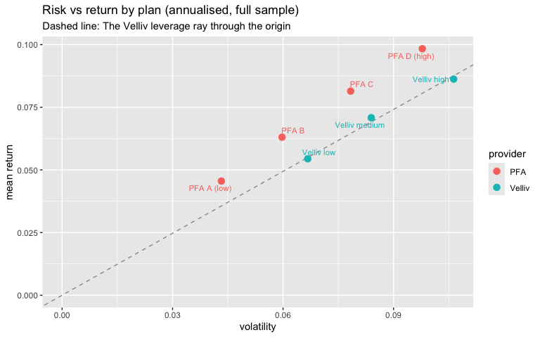

The three Velliv plans lie close to one ray, the signature of leverage. PFA’s profiles sit a little off it, the small bend the decomposition above quantified.

## Diversifying across providers: Variance drain and certainty equivalent

The crossing and Sharpe results concern one provider’s menu. A separate question is what the return moments say about holding *both* providers at one risk level, for example Velliv high together with PFA high. This is the diversification the investor tool weighs against fees. We derive its value here from the moments alone, and the tool applies it to costs.

**Variance drain.** Compound growth sits below the arithmetic mean by half the variance. If a plan’s simple returns have arithmetic mean $a$ and variance $\sigma^2$, wealth compounds at about $g\approx a-\tfrac12\sigma^2$ per period. Cutting variance therefore lifts the compound rate one part in two: A reduction $\Delta\sigma^2$ raises $g$ by $\Delta\sigma^2/2$.

**A 50/50 blend cuts variance.** Take two plans of equal variance $\sigma^2$ and correlation $\rho$. The equal-weight blend has variance $\tfrac12\sigma^2(1+\rho)$, a reduction of $\tfrac12\sigma^2(1-\rho)$. Write $\sigma^2_{\mathrm{gap}}=\operatorname{Var}(r_A-r_B)=2\sigma^2(1-\rho)$ for the variance of the gap between the two plans. The reduction is then $\sigma^2_{\mathrm{gap}}/4$, and the compound-growth lift is
$$\Delta g=\tfrac12\cdot\frac{\sigma^2_{\mathrm{gap}}}{4}=\frac{\sigma^2_{\mathrm{gap}}}{8}.$$

**Certainty equivalent.** A saver with constant relative risk aversion $\gamma$ values a variance cut at $\tfrac12\gamma$ times its size, so the certainty-equivalent value of holding both plans rather than one is
$$\mathrm{CE}\approx\tfrac12\gamma\cdot\frac{\sigma^2_{\mathrm{gap}}}{4}=\frac{\gamma\,\sigma^2_{\mathrm{gap}}}{8}.$$
The variance drain is the case $\gamma=1$, log utility, where the risk-adjusted value equals the raw growth lift. The value scales linearly in risk aversion above that.

**Two sources over a horizon.** Over $T$ periods the gap between the two plans’ cumulative log returns has two parts. One is path noise, the accumulation of the per-period gap, which grows linearly in $T$. The other is uncertainty about the *relative* drift, since which provider compounds faster is not known in advance, and this grows as $T^2$, so it dominates at long horizons. Both enter $\sigma^2_{\mathrm{gap}}$ and so the certainty equivalent. The estimation part is the larger stake for a long-horizon saver, and it is exactly what the data cannot pin down.

Diversification value of a 50/50 cross-provider blend at one risk level, from the return moments (full sample, n = 142). $\Delta g$ is the variance drain, equal to the certainty equivalent at $\gamma=1$; $\Delta g$ and CE are in basis points per year. A mean-variance, body-of-the-distribution figure.

| blend | $\sigma_{\mathrm{gap}}$ (ann.) | $\Delta g$ (bp/yr) | CE, $\gamma=2$ (bp/yr) | CE, $\gamma=4$ (bp/yr) |
| --- | --- | --- | --- | --- |
| Velliv high + PFA high | 2.8% | 1.0 | 1.9 | 3.8 |
| Velliv medium + PFA medium | 3.1% | 1.2 | 2.5 | 4.9 |

**A body result, not a tail result.** This is a mean-variance argument, valid for the centre of the distribution where a variance is a meaningful summary. The report’s central finding is that the tail is heavy and the variance may not be finite, in which case $\sigma^2$ and everything built on it lose their meaning. The value above is therefore the diversification benefit in the body. Whether holding both providers helps in a crash is a tail question, and the investor tool takes it up with a joint simulation.

### The provider gap is one realised path

The certainty equivalent above prices the uncertainty about *which* provider compounds faster. That uncertainty is real: Over the sample the two high-risk plans drift apart, but by a margin the data cannot distinguish from zero.

Realised return gap, PFA high minus Velliv high (full sample, n = 142).

| annualised gap | standard error | t |
| --- | --- | --- |
| +1.2 pp/yr | 0.8 pp/yr | 1.5 |

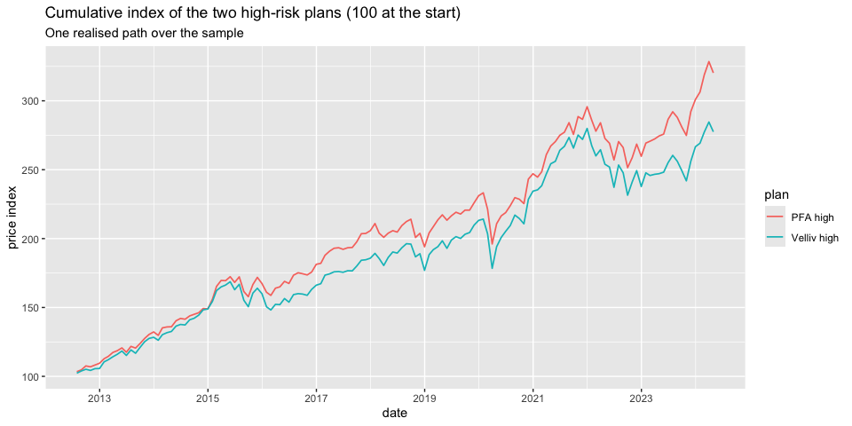

The paths separate, yet with $t\approx1.5$ the gap is not distinguishable from zero. Which provider leads is not something the data establish in advance, which is exactly the uncertainty the certainty equivalent prices.

# Compare pension plans

## Risk of loss

Risk of loss at least as big as row name in percent for a single period (year).

Skewed $t$-distribution (sstd):

|  | vmr | vhr | pmr | phr | mmr | mhr | vmr_phr | vhr_pmr |
| --- | --- | --- | --- | --- | --- | --- | --- | --- |
| 0 | 32.333 | 33.000 | 30.167 | 31.667 | 31.167 | 32.167 | 31.833 | 31.667 |
| 5 | 2.500 | 4.167 | 0.667 | 3.167 | 1.500 | 3.500 | 2.667 | 2.500 |
| 10 | 0.167 | 0.500 | 0.000 | 0.167 | 0.000 | 0.333 | 0.167 | 0.167 |
| 25 | 0.000 | 0.000 | 0.000 | 0.000 | 0.000 | 0.000 | 0.000 | 0.000 |
| 50 | 0.000 | 0.000 | 0.000 | 0.000 | 0.000 | 0.000 | 0.000 | 0.000 |
| 90 | 0.000 | 0.000 | 0.000 | 0.000 | 0.000 | 0.000 | 0.000 | 0.000 |
| 99 | 0.000 | 0.000 | 0.000 | 0.000 | 0.000 | 0.000 | 0.000 | 0.000 |

Standardized $t$-distribution (std):

|  | vmr | vhr | pmr | phr | mmr | mhr | vmr_phr | vhr_pmr |
| --- | --- | --- | --- | --- | --- | --- | --- | --- |
| 0 | 31.5 | 32.167 | 28.167 | 31.333 | 29.5 | 31.167 | 30.833 | 30.333 |
| 5 | 1.0 | 2.167 | 0.167 | 1.500 | 0.5 | 1.833 | 1.167 | 1.000 |
| 10 | 0.0 | 0.000 | 0.000 | 0.000 | 0.0 | 0.000 | 0.000 | 0.000 |
| 25 | 0.0 | 0.000 | 0.000 | 0.000 | 0.0 | 0.000 | 0.000 | 0.000 |
| 50 | 0.0 | 0.000 | 0.000 | 0.000 | 0.0 | 0.000 | 0.000 | 0.000 |
| 90 | 0.0 | 0.000 | 0.000 | 0.000 | 0.0 | 0.000 | 0.000 | 0.000 |
| 99 | 0.0 | 0.000 | 0.000 | 0.000 | 0.0 | 0.000 | 0.000 | 0.000 |

Normal distribution:

|  | vmr | vhr | pmr | phr | mmr | mhr | vmr_phr | vhr_pmr |
| --- | --- | --- | --- | --- | --- | --- | --- | --- |
| 0 | 40.333 | 40.667 | 37.833 | 38.500 | 39.167 | 39.500 | 39.167 | 39.667 |
| 5 | 0.500 | 2.333 | 0.000 | 1.333 | 0.000 | 1.667 | 0.833 | 0.500 |
| 10 | 0.000 | 0.000 | 0.000 | 0.000 | 0.000 | 0.000 | 0.000 | 0.000 |
| 25 | 0.000 | 0.000 | 0.000 | 0.000 | 0.000 | 0.000 | 0.000 | 0.000 |
| 50 | 0.000 | 0.000 | 0.000 | 0.000 | 0.000 | 0.000 | 0.000 | 0.000 |
| 90 | 0.000 | 0.000 | 0.000 | 0.000 | 0.000 | 0.000 | 0.000 | 0.000 |
| 99 | 0.000 | 0.000 | 0.000 | 0.000 | 0.000 | 0.000 | 0.000 | 0.000 |

### Worst ranking for loss percentiles

Skewed $t$-distribution (sstd):

| 0 | ranking | 5 | ranking | 10 | ranking | 25 | ranking | 50 | ranking | 90 | ranking | 99 | ranking |
| --- | --- | --- | --- | --- | --- | --- | --- | --- | --- | --- | --- | --- | --- |
| 33.000 | vhr | 4.167 | vhr | 0.500 | vhr | 0 | vmr | 0 | vmr | 0 | vmr | 0 | vmr |
| 32.333 | vmr | 3.500 | mhr | 0.333 | mhr | 0 | vhr | 0 | vhr | 0 | vhr | 0 | vhr |
| 32.167 | mhr | 3.167 | phr | 0.167 | vmr | 0 | pmr | 0 | pmr | 0 | pmr | 0 | pmr |
| 31.833 | vmr_phr | 2.667 | vmr_phr | 0.167 | phr | 0 | phr | 0 | phr | 0 | phr | 0 | phr |
| 31.667 | phr | 2.500 | vmr | 0.167 | vmr_phr | 0 | mmr | 0 | mmr | 0 | mmr | 0 | mmr |
| 31.667 | vhr_pmr | 2.500 | vhr_pmr | 0.167 | vhr_pmr | 0 | mhr | 0 | mhr | 0 | mhr | 0 | mhr |
| 31.167 | mmr | 1.500 | mmr | 0.000 | pmr | 0 | vmr_phr | 0 | vmr_phr | 0 | vmr_phr | 0 | vmr_phr |
| 30.167 | pmr | 0.667 | pmr | 0.000 | mmr | 0 | vhr_pmr | 0 | vhr_pmr | 0 | vhr_pmr | 0 | vhr_pmr |

Standardized $t$-distribution (std):

| 0 | ranking | 5 | ranking | 10 | ranking | 25 | ranking | 50 | ranking | 90 | ranking | 99 | ranking |
| --- | --- | --- | --- | --- | --- | --- | --- | --- | --- | --- | --- | --- | --- |
| 32.167 | vhr | 2.167 | vhr | 0 | vmr | 0 | vmr | 0 | vmr | 0 | vmr | 0 | vmr |
| 31.500 | vmr | 1.833 | mhr | 0 | vhr | 0 | vhr | 0 | vhr | 0 | vhr | 0 | vhr |
| 31.333 | phr | 1.500 | phr | 0 | pmr | 0 | pmr | 0 | pmr | 0 | pmr | 0 | pmr |
| 31.167 | mhr | 1.167 | vmr_phr | 0 | phr | 0 | phr | 0 | phr | 0 | phr | 0 | phr |
| 30.833 | vmr_phr | 1.000 | vmr | 0 | mmr | 0 | mmr | 0 | mmr | 0 | mmr | 0 | mmr |
| 30.333 | vhr_pmr | 1.000 | vhr_pmr | 0 | mhr | 0 | mhr | 0 | mhr | 0 | mhr | 0 | mhr |
| 29.500 | mmr | 0.500 | mmr | 0 | vmr_phr | 0 | vmr_phr | 0 | vmr_phr | 0 | vmr_phr | 0 | vmr_phr |
| 28.167 | pmr | 0.167 | pmr | 0 | vhr_pmr | 0 | vhr_pmr | 0 | vhr_pmr | 0 | vhr_pmr | 0 | vhr_pmr |

Normal distribution:

| 0 | ranking | 5 | ranking | 10 | ranking | 25 | ranking | 50 | ranking | 90 | ranking | 99 | ranking |
| --- | --- | --- | --- | --- | --- | --- | --- | --- | --- | --- | --- | --- | --- |
| 40.667 | vhr | 2.333 | vhr | 0 | vmr | 0 | vmr | 0 | vmr | 0 | vmr | 0 | vmr |
| 40.333 | vmr | 1.667 | mhr | 0 | vhr | 0 | vhr | 0 | vhr | 0 | vhr | 0 | vhr |
| 39.667 | vhr_pmr | 1.333 | phr | 0 | pmr | 0 | pmr | 0 | pmr | 0 | pmr | 0 | pmr |
| 39.500 | mhr | 0.833 | vmr_phr | 0 | phr | 0 | phr | 0 | phr | 0 | phr | 0 | phr |
| 39.167 | mmr | 0.500 | vmr | 0 | mmr | 0 | mmr | 0 | mmr | 0 | mmr | 0 | mmr |
| 39.167 | vmr_phr | 0.500 | vhr_pmr | 0 | mhr | 0 | mhr | 0 | mhr | 0 | mhr | 0 | mhr |
| 38.500 | phr | 0.000 | pmr | 0 | vmr_phr | 0 | vmr_phr | 0 | vmr_phr | 0 | vmr_phr | 0 | vmr_phr |
| 37.833 | pmr | 0.000 | mmr | 0 | vhr_pmr | 0 | vhr_pmr | 0 | vhr_pmr | 0 | vhr_pmr | 0 | vhr_pmr |

## Chance of min gains

Chance of gains of at least `x` percent for a single period (year).  
`x` values are row names.

Skewed $t$-distribution (sstd):

|  | vmr | vhr | pmr | phr | mmr | mhr | vmr_phr | vhr_pmr |
| --- | --- | --- | --- | --- | --- | --- | --- | --- |
| 0 | 67.667 | 67.000 | 69.833 | 68.333 | 68.833 | 67.833 | 68.167 | 68.333 |
| 5 | 1.167 | 3.833 | 0.167 | 3.667 | 0.500 | 3.333 | 2.167 | 1.333 |
| 10 | 0.000 | 0.000 | 0.000 | 0.000 | 0.000 | 0.000 | 0.000 | 0.000 |
| 25 | 0.000 | 0.000 | 0.000 | 0.000 | 0.000 | 0.000 | 0.000 | 0.000 |
| 50 | 0.000 | 0.000 | 0.000 | 0.000 | 0.000 | 0.000 | 0.000 | 0.000 |
| 100 | 0.000 | 0.000 | 0.000 | 0.000 | 0.000 | 0.000 | 0.000 | 0.000 |

Standardized $t$-distribution (std):

|  | vmr | vhr | pmr | phr | mmr | mhr | vmr_phr | vhr_pmr |
| --- | --- | --- | --- | --- | --- | --- | --- | --- |
| 0 | 68.5 | 67.833 | 71.833 | 68.667 | 70.500 | 68.833 | 69.167 | 69.667 |
| 5 | 4.0 | 7.833 | 1.167 | 6.833 | 2.333 | 7.167 | 5.333 | 4.000 |
| 10 | 0.0 | 0.667 | 0.000 | 0.333 | 0.000 | 0.500 | 0.167 | 0.167 |
| 25 | 0.0 | 0.000 | 0.000 | 0.000 | 0.000 | 0.000 | 0.000 | 0.000 |
| 50 | 0.0 | 0.000 | 0.000 | 0.000 | 0.000 | 0.000 | 0.000 | 0.000 |
| 100 | 0.0 | 0.000 | 0.000 | 0.000 | 0.000 | 0.000 | 0.000 | 0.000 |

Normal distribution:

|  | vmr | vhr | pmr | phr | mmr | mhr | vmr_phr | vhr_pmr |
| --- | --- | --- | --- | --- | --- | --- | --- | --- |
| 0 | 59.667 | 59.333 | 62.167 | 61.500 | 60.833 | 60.5 | 60.833 | 60.333 |
| 5 | 3.333 | 8.333 | 0.167 | 7.167 | 1.333 | 7.5 | 5.167 | 3.500 |
| 10 | 0.000 | 0.000 | 0.000 | 0.000 | 0.000 | 0.0 | 0.000 | 0.000 |
| 25 | 0.000 | 0.000 | 0.000 | 0.000 | 0.000 | 0.0 | 0.000 | 0.000 |
| 50 | 0.000 | 0.000 | 0.000 | 0.000 | 0.000 | 0.0 | 0.000 | 0.000 |
| 100 | 0.000 | 0.000 | 0.000 | 0.000 | 0.000 | 0.0 | 0.000 | 0.000 |

### Best ranking for gains percentiles

Skewed $t$-distribution (sstd):

| 0 | ranking | 5 | ranking | 10 | ranking | 25 | ranking | 50 | ranking | 100 | ranking |
| --- | --- | --- | --- | --- | --- | --- | --- | --- | --- | --- | --- |
| 69.833 | pmr | 3.833 | vhr | 0 | vmr | 0 | vmr | 0 | vmr | 0 | vmr |
| 68.833 | mmr | 3.667 | phr | 0 | vhr | 0 | vhr | 0 | vhr | 0 | vhr |
| 68.333 | phr | 3.333 | mhr | 0 | pmr | 0 | pmr | 0 | pmr | 0 | pmr |
| 68.333 | vhr_pmr | 2.167 | vmr_phr | 0 | phr | 0 | phr | 0 | phr | 0 | phr |
| 68.167 | vmr_phr | 1.333 | vhr_pmr | 0 | mmr | 0 | mmr | 0 | mmr | 0 | mmr |
| 67.833 | mhr | 1.167 | vmr | 0 | mhr | 0 | mhr | 0 | mhr | 0 | mhr |
| 67.667 | vmr | 0.500 | mmr | 0 | vmr_phr | 0 | vmr_phr | 0 | vmr_phr | 0 | vmr_phr |
| 67.000 | vhr | 0.167 | pmr | 0 | vhr_pmr | 0 | vhr_pmr | 0 | vhr_pmr | 0 | vhr_pmr |

Standardized $t$-distribution (std):

| 0 | ranking | 5 | ranking | 10 | ranking | 25 | ranking | 50 | ranking | 100 | ranking |
| --- | --- | --- | --- | --- | --- | --- | --- | --- | --- | --- | --- |
| 71.833 | pmr | 7.833 | vhr | 0.667 | vhr | 0 | vmr | 0 | vmr | 0 | vmr |
| 70.500 | mmr | 7.167 | mhr | 0.500 | mhr | 0 | vhr | 0 | vhr | 0 | vhr |
| 69.667 | vhr_pmr | 6.833 | phr | 0.333 | phr | 0 | pmr | 0 | pmr | 0 | pmr |
| 69.167 | vmr_phr | 5.333 | vmr_phr | 0.167 | vmr_phr | 0 | phr | 0 | phr | 0 | phr |
| 68.833 | mhr | 4.000 | vmr | 0.167 | vhr_pmr | 0 | mmr | 0 | mmr | 0 | mmr |
| 68.667 | phr | 4.000 | vhr_pmr | 0.000 | vmr | 0 | mhr | 0 | mhr | 0 | mhr |
| 68.500 | vmr | 2.333 | mmr | 0.000 | pmr | 0 | vmr_phr | 0 | vmr_phr | 0 | vmr_phr |
| 67.833 | vhr | 1.167 | pmr | 0.000 | mmr | 0 | vhr_pmr | 0 | vhr_pmr | 0 | vhr_pmr |

Normal distribution:

| 0 | ranking | 5 | ranking | 10 | ranking | 25 | ranking | 50 | ranking | 100 | ranking |
| --- | --- | --- | --- | --- | --- | --- | --- | --- | --- | --- | --- |
| 62.167 | pmr | 8.333 | vhr | 0 | vmr | 0 | vmr | 0 | vmr | 0 | vmr |
| 61.500 | phr | 7.500 | mhr | 0 | vhr | 0 | vhr | 0 | vhr | 0 | vhr |
| 60.833 | mmr | 7.167 | phr | 0 | pmr | 0 | pmr | 0 | pmr | 0 | pmr |
| 60.833 | vmr_phr | 5.167 | vmr_phr | 0 | phr | 0 | phr | 0 | phr | 0 | phr |
| 60.500 | mhr | 3.500 | vhr_pmr | 0 | mmr | 0 | mmr | 0 | mmr | 0 | mmr |
| 60.333 | vhr_pmr | 3.333 | vmr | 0 | mhr | 0 | mhr | 0 | mhr | 0 | mhr |
| 59.667 | vmr | 1.333 | mmr | 0 | vmr_phr | 0 | vmr_phr | 0 | vmr_phr | 0 | vmr_phr |
| 59.333 | vhr | 0.167 | pmr | 0 | vhr_pmr | 0 | vhr_pmr | 0 | vhr_pmr | 0 | vhr_pmr |

## MC risk percentiles

Risk of loss at least as big as row name in percent from first to last period.

Skewed $t$-distribution (sstd):

|  | vmr | vhr | pmr | phr | mmr | mhr | vmr_phr | vhr_pmr |
| --- | --- | --- | --- | --- | --- | --- | --- | --- |
| 0 | 17.07 | 18.84 | 9.95 | 12.39 | 14.82 | 15.14 | 13.99 | 15.97 |
| 5 | 8.87 | 11.40 | 3.54 | 6.71 | 6.91 | 8.47 | 7.61 | 8.21 |
| 10 | 4.26 | 6.49 | 1.08 | 3.46 | 2.88 | 4.42 | 3.70 | 3.63 |
| 25 | 0.45 | 1.02 | 0.06 | 0.35 | 0.20 | 0.42 | 0.32 | 0.34 |
| 50 | 0.03 | 0.01 | 0.00 | 0.03 | 0.03 | 0.03 | 0.02 | 0.00 |
| 90 | 0.00 | 0.00 | 0.00 | 0.00 | 0.00 | 0.00 | 0.00 | 0.00 |
| 99 | 0.00 | 0.00 | 0.00 | 0.00 | 0.00 | 0.00 | 0.00 | 0.00 |

Standardized $t$-distribution (std):

|  | vmr | vhr | pmr | phr | mmr | mhr | vmr_phr | vhr_pmr |
| --- | --- | --- | --- | --- | --- | --- | --- | --- |
| 0 | 6.21 | 6.74 | 4.20 | 4.67 | 4.61 | 5.48 | 4.93 | 5.38 |
| 5 | 2.47 | 3.34 | 1.20 | 1.93 | 1.57 | 2.62 | 2.15 | 2.26 |
| 10 | 0.88 | 1.49 | 0.34 | 0.70 | 0.43 | 1.19 | 0.76 | 0.78 |
| 25 | 0.05 | 0.17 | 0.05 | 0.05 | 0.03 | 0.07 | 0.04 | 0.05 |
| 50 | 0.00 | 0.00 | 0.00 | 0.00 | 0.00 | 0.01 | 0.01 | 0.01 |
| 90 | 0.00 | 0.00 | 0.00 | 0.00 | 0.00 | 0.00 | 0.00 | 0.00 |
| 99 | 0.00 | 0.00 | 0.00 | 0.00 | 0.00 | 0.00 | 0.00 | 0.00 |

Normal distribution:

|  | vmr | vhr | pmr | phr | mmr | mhr | vmr_phr | vhr_pmr |
| --- | --- | --- | --- | --- | --- | --- | --- | --- |
| 0 | 13.93 | 16.01 | 9.13 | 10.13 | 12.30 | 12.31 | 11.87 | 12.83 |
| 5 | 5.80 | 8.34 | 2.18 | 4.51 | 4.09 | 5.89 | 4.91 | 5.38 |
| 10 | 1.85 | 3.75 | 0.37 | 1.61 | 0.99 | 2.37 | 1.86 | 1.68 |
| 25 | 0.00 | 0.11 | 0.00 | 0.01 | 0.00 | 0.01 | 0.04 | 0.00 |
| 50 | 0.00 | 0.00 | 0.00 | 0.00 | 0.00 | 0.00 | 0.00 | 0.00 |
| 90 | 0.00 | 0.00 | 0.00 | 0.00 | 0.00 | 0.00 | 0.00 | 0.00 |
| 99 | 0.00 | 0.00 | 0.00 | 0.00 | 0.00 | 0.00 | 0.00 | 0.00 |

### Worst ranking for MC loss percentiles

Skewed $t$-distribution (sstd):

| 0 | ranking | 5 | ranking | 10 | ranking | 25 | ranking | 50 | ranking | 90 | ranking | 99 | ranking |
| --- | --- | --- | --- | --- | --- | --- | --- | --- | --- | --- | --- | --- | --- |
| 18.84 | vhr | 11.40 | vhr | 6.49 | vhr | 1.02 | vhr | 0.03 | vmr | 0 | vmr | 0 | vmr |
| 17.07 | vmr | 8.87 | vmr | 4.42 | mhr | 0.45 | vmr | 0.03 | phr | 0 | vhr | 0 | vhr |
| 15.97 | vhr_pmr | 8.47 | mhr | 4.26 | vmr | 0.42 | mhr | 0.03 | mmr | 0 | pmr | 0 | pmr |
| 15.14 | mhr | 8.21 | vhr_pmr | 3.70 | vmr_phr | 0.35 | phr | 0.03 | mhr | 0 | phr | 0 | phr |
| 14.82 | mmr | 7.61 | vmr_phr | 3.63 | vhr_pmr | 0.34 | vhr_pmr | 0.02 | vmr_phr | 0 | mmr | 0 | mmr |
| 13.99 | vmr_phr | 6.91 | mmr | 3.46 | phr | 0.32 | vmr_phr | 0.01 | vhr | 0 | mhr | 0 | mhr |
| 12.39 | phr | 6.71 | phr | 2.88 | mmr | 0.20 | mmr | 0.00 | pmr | 0 | vmr_phr | 0 | vmr_phr |
| 9.95 | pmr | 3.54 | pmr | 1.08 | pmr | 0.06 | pmr | 0.00 | vhr_pmr | 0 | vhr_pmr | 0 | vhr_pmr |

Standardized $t$-distribution (std):

| 0 | ranking | 5 | ranking | 10 | ranking | 25 | ranking | 50 | ranking | 90 | ranking | 99 | ranking |
| --- | --- | --- | --- | --- | --- | --- | --- | --- | --- | --- | --- | --- | --- |
| 6.74 | vhr | 3.34 | vhr | 1.49 | vhr | 0.17 | vhr | 0.01 | mhr | 0 | vmr | 0 | vmr |
| 6.21 | vmr | 2.62 | mhr | 1.19 | mhr | 0.07 | mhr | 0.01 | vmr_phr | 0 | vhr | 0 | vhr |
| 5.48 | mhr | 2.47 | vmr | 0.88 | vmr | 0.05 | vmr | 0.01 | vhr_pmr | 0 | pmr | 0 | pmr |
| 5.38 | vhr_pmr | 2.26 | vhr_pmr | 0.78 | vhr_pmr | 0.05 | pmr | 0.00 | vmr | 0 | phr | 0 | phr |
| 4.93 | vmr_phr | 2.15 | vmr_phr | 0.76 | vmr_phr | 0.05 | phr | 0.00 | vhr | 0 | mmr | 0 | mmr |
| 4.67 | phr | 1.93 | phr | 0.70 | phr | 0.05 | vhr_pmr | 0.00 | pmr | 0 | mhr | 0 | mhr |
| 4.61 | mmr | 1.57 | mmr | 0.43 | mmr | 0.04 | vmr_phr | 0.00 | phr | 0 | vmr_phr | 0 | vmr_phr |
| 4.20 | pmr | 1.20 | pmr | 0.34 | pmr | 0.03 | mmr | 0.00 | mmr | 0 | vhr_pmr | 0 | vhr_pmr |

Normal distribution:

| 0 | ranking | 5 | ranking | 10 | ranking | 25 | ranking | 50 | ranking | 90 | ranking | 99 | ranking |
| --- | --- | --- | --- | --- | --- | --- | --- | --- | --- | --- | --- | --- | --- |
| 16.01 | vhr | 8.34 | vhr | 3.75 | vhr | 0.11 | vhr | 0 | vmr | 0 | vmr | 0 | vmr |
| 13.93 | vmr | 5.89 | mhr | 2.37 | mhr | 0.04 | vmr_phr | 0 | vhr | 0 | vhr | 0 | vhr |
| 12.83 | vhr_pmr | 5.80 | vmr | 1.86 | vmr_phr | 0.01 | phr | 0 | pmr | 0 | pmr | 0 | pmr |
| 12.31 | mhr | 5.38 | vhr_pmr | 1.85 | vmr | 0.01 | mhr | 0 | phr | 0 | phr | 0 | phr |
| 12.30 | mmr | 4.91 | vmr_phr | 1.68 | vhr_pmr | 0.00 | vmr | 0 | mmr | 0 | mmr | 0 | mmr |
| 11.87 | vmr_phr | 4.51 | phr | 1.61 | phr | 0.00 | pmr | 0 | mhr | 0 | mhr | 0 | mhr |
| 10.13 | phr | 4.09 | mmr | 0.99 | mmr | 0.00 | mmr | 0 | vmr_phr | 0 | vmr_phr | 0 | vmr_phr |
| 9.13 | pmr | 2.18 | pmr | 0.37 | pmr | 0.00 | vhr_pmr | 0 | vhr_pmr | 0 | vhr_pmr | 0 | vhr_pmr |

## MC gains percentiles

Skewed $t$-distribution (sstd):

|  | vmr | vhr | pmr | phr | mmr | mhr | vmr_phr | vhr_pmr |
| --- | --- | --- | --- | --- | --- | --- | --- | --- |
| 0 | 82.93 | 81.16 | 90.05 | 87.61 | 85.18 | 84.86 | 86.01 | 84.03 |
| 5 | 70.76 | 71.99 | 76.14 | 79.04 | 72.11 | 75.08 | 76.41 | 73.09 |
| 10 | 55.32 | 60.46 | 55.17 | 68.30 | 54.87 | 63.86 | 63.19 | 58.42 |
| 25 | 13.52 | 24.27 | 4.49 | 30.34 | 8.63 | 26.11 | 21.38 | 15.78 |
| 50 | 0.27 | 1.55 | 0.00 | 1.67 | 0.05 | 1.61 | 0.52 | 0.20 |
| 100 | 0.01 | 0.01 | 0.00 | 0.00 | 0.00 | 0.00 | 0.01 | 0.01 |
| 200 | 0.00 | 0.00 | 0.00 | 0.00 | 0.00 | 0.00 | 0.01 | 0.00 |
| 300 | 0.00 | 0.00 | 0.00 | 0.00 | 0.00 | 0.00 | 0.00 | 0.00 |
| 400 | 0.00 | 0.00 | 0.00 | 0.00 | 0.00 | 0.00 | 0.00 | 0.00 |
| 500 | 0.00 | 0.00 | 0.00 | 0.00 | 0.00 | 0.00 | 0.00 | 0.00 |
| 1000 | 0.00 | 0.00 | 0.00 | 0.00 | 0.00 | 0.00 | 0.00 | 0.00 |

Standardized $t$-distribution (std):

|  | vmr | vhr | pmr | phr | mmr | mhr | vmr_phr | vhr_pmr |
| --- | --- | --- | --- | --- | --- | --- | --- | --- |
| 0 | 93.79 | 93.26 | 95.80 | 95.33 | 95.39 | 94.52 | 95.07 | 94.62 |
| 5 | 86.63 | 87.86 | 87.73 | 90.31 | 88.89 | 88.92 | 89.29 | 88.12 |
| 10 | 74.95 | 79.28 | 71.91 | 82.31 | 76.03 | 81.41 | 80.43 | 77.28 |
| 25 | 29.38 | 44.36 | 13.85 | 44.89 | 24.06 | 45.54 | 39.68 | 33.17 |
| 50 | 1.83 | 7.27 | 0.21 | 5.44 | 0.73 | 6.37 | 3.57 | 2.11 |
| 100 | 0.03 | 0.13 | 0.01 | 0.05 | 0.03 | 0.03 | 0.04 | 0.02 |
| 200 | 0.00 | 0.01 | 0.00 | 0.00 | 0.01 | 0.00 | 0.00 | 0.01 |
| 300 | 0.00 | 0.01 | 0.00 | 0.00 | 0.01 | 0.00 | 0.00 | 0.01 |
| 400 | 0.00 | 0.01 | 0.00 | 0.00 | 0.01 | 0.00 | 0.00 | 0.00 |
| 500 | 0.00 | 0.01 | 0.00 | 0.00 | 0.00 | 0.00 | 0.00 | 0.00 |
| 1000 | 0.00 | 0.01 | 0.00 | 0.00 | 0.00 | 0.00 | 0.00 | 0.00 |

Normal distribution:

|  | vmr | vhr | pmr | phr | mmr | mhr | vmr_phr | vhr_pmr |
| --- | --- | --- | --- | --- | --- | --- | --- | --- |
| 0 | 86.07 | 83.99 | 90.87 | 89.87 | 87.70 | 87.69 | 88.13 | 87.17 |
| 5 | 72.88 | 73.65 | 75.16 | 80.75 | 73.79 | 77.80 | 77.45 | 75.20 |
| 10 | 56.82 | 61.39 | 51.06 | 68.10 | 54.76 | 65.72 | 63.56 | 59.08 |
| 25 | 14.87 | 25.32 | 4.59 | 28.98 | 9.29 | 27.71 | 21.63 | 16.53 |
| 50 | 0.27 | 2.15 | 0.01 | 1.92 | 0.03 | 2.12 | 0.98 | 0.33 |
| 100 | 0.00 | 0.00 | 0.00 | 0.00 | 0.00 | 0.00 | 0.00 | 0.00 |
| 200 | 0.00 | 0.00 | 0.00 | 0.00 | 0.00 | 0.00 | 0.00 | 0.00 |
| 300 | 0.00 | 0.00 | 0.00 | 0.00 | 0.00 | 0.00 | 0.00 | 0.00 |
| 400 | 0.00 | 0.00 | 0.00 | 0.00 | 0.00 | 0.00 | 0.00 | 0.00 |
| 500 | 0.00 | 0.00 | 0.00 | 0.00 | 0.00 | 0.00 | 0.00 | 0.00 |
| 1000 | 0.00 | 0.00 | 0.00 | 0.00 | 0.00 | 0.00 | 0.00 | 0.00 |

### Best ranking for MC gains percentiles

Skewed $t$-distribution (sstd):

| 0 | ranking | 5 | ranking | 10 | ranking | 25 | ranking | 50 | ranking | 100 | ranking |
| --- | --- | --- | --- | --- | --- | --- | --- | --- | --- | --- | --- |
| 90.05 | pmr | 79.04 | phr | 68.30 | phr | 30.34 | phr | 1.67 | phr | 0.01 | vmr |
| 87.61 | phr | 76.41 | vmr_phr | 63.86 | mhr | 26.11 | mhr | 1.61 | mhr | 0.01 | vhr |
| 86.01 | vmr_phr | 76.14 | pmr | 63.19 | vmr_phr | 24.27 | vhr | 1.55 | vhr | 0.01 | vmr_phr |
| 85.18 | mmr | 75.08 | mhr | 60.46 | vhr | 21.38 | vmr_phr | 0.52 | vmr_phr | 0.01 | vhr_pmr |
| 84.86 | mhr | 73.09 | vhr_pmr | 58.42 | vhr_pmr | 15.78 | vhr_pmr | 0.27 | vmr | 0.00 | pmr |
| 84.03 | vhr_pmr | 72.11 | mmr | 55.32 | vmr | 13.52 | vmr | 0.20 | vhr_pmr | 0.00 | phr |
| 82.93 | vmr | 71.99 | vhr | 55.17 | pmr | 8.63 | mmr | 0.05 | mmr | 0.00 | mmr |
| 81.16 | vhr | 70.76 | vmr | 54.87 | mmr | 4.49 | pmr | 0.00 | pmr | 0.00 | mhr |

| 200 | ranking | 300 | ranking | 400 | ranking | 500 | ranking | 1000 | ranking |
| --- | --- | --- | --- | --- | --- | --- | --- | --- | --- |
| 0.01 | vmr_phr | 0 | vmr | 0 | vmr | 0 | vmr | 0 | vmr |
| 0.00 | vmr | 0 | vhr | 0 | vhr | 0 | vhr | 0 | vhr |
| 0.00 | vhr | 0 | pmr | 0 | pmr | 0 | pmr | 0 | pmr |
| 0.00 | pmr | 0 | phr | 0 | phr | 0 | phr | 0 | phr |
| 0.00 | phr | 0 | mmr | 0 | mmr | 0 | mmr | 0 | mmr |
| 0.00 | mmr | 0 | mhr | 0 | mhr | 0 | mhr | 0 | mhr |
| 0.00 | mhr | 0 | vmr_phr | 0 | vmr_phr | 0 | vmr_phr | 0 | vmr_phr |
| 0.00 | vhr_pmr | 0 | vhr_pmr | 0 | vhr_pmr | 0 | vhr_pmr | 0 | vhr_pmr |

Standardized $t$-distribution (std):

| 0 | ranking | 5 | ranking | 10 | ranking | 25 | ranking | 50 | ranking | 100 | ranking |
| --- | --- | --- | --- | --- | --- | --- | --- | --- | --- | --- | --- |
| 95.80 | pmr | 90.31 | phr | 82.31 | phr | 45.54 | mhr | 7.27 | vhr | 0.13 | vhr |
| 95.39 | mmr | 89.29 | vmr_phr | 81.41 | mhr | 44.89 | phr | 6.37 | mhr | 0.05 | phr |
| 95.33 | phr | 88.92 | mhr | 80.43 | vmr_phr | 44.36 | vhr | 5.44 | phr | 0.04 | vmr_phr |
| 95.07 | vmr_phr | 88.89 | mmr | 79.28 | vhr | 39.68 | vmr_phr | 3.57 | vmr_phr | 0.03 | vmr |
| 94.62 | vhr_pmr | 88.12 | vhr_pmr | 77.28 | vhr_pmr | 33.17 | vhr_pmr | 2.11 | vhr_pmr | 0.03 | mmr |
| 94.52 | mhr | 87.86 | vhr | 76.03 | mmr | 29.38 | vmr | 1.83 | vmr | 0.03 | mhr |
| 93.79 | vmr | 87.73 | pmr | 74.95 | vmr | 24.06 | mmr | 0.73 | mmr | 0.02 | vhr_pmr |
| 93.26 | vhr | 86.63 | vmr | 71.91 | pmr | 13.85 | pmr | 0.21 | pmr | 0.01 | pmr |

| 200 | ranking | 300 | ranking | 400 | ranking | 500 | ranking | 1000 | ranking |
| --- | --- | --- | --- | --- | --- | --- | --- | --- | --- |
| 0.01 | vhr | 0.01 | vhr | 0.01 | vhr | 0.01 | vhr | 0.01 | vhr |
| 0.01 | mmr | 0.01 | mmr | 0.01 | mmr | 0.00 | vmr | 0.00 | vmr |
| 0.01 | vhr_pmr | 0.01 | vhr_pmr | 0.00 | vmr | 0.00 | pmr | 0.00 | pmr |
| 0.00 | vmr | 0.00 | vmr | 0.00 | pmr | 0.00 | phr | 0.00 | phr |
| 0.00 | pmr | 0.00 | pmr | 0.00 | phr | 0.00 | mmr | 0.00 | mmr |
| 0.00 | phr | 0.00 | phr | 0.00 | mhr | 0.00 | mhr | 0.00 | mhr |
| 0.00 | mhr | 0.00 | mhr | 0.00 | vmr_phr | 0.00 | vmr_phr | 0.00 | vmr_phr |
| 0.00 | vmr_phr | 0.00 | vmr_phr | 0.00 | vhr_pmr | 0.00 | vhr_pmr | 0.00 | vhr_pmr |

Normal distribution:

| 0 | ranking | 5 | ranking | 10 | ranking | 25 | ranking | 50 | ranking | 100 | ranking |
| --- | --- | --- | --- | --- | --- | --- | --- | --- | --- | --- | --- |
| 90.87 | pmr | 80.75 | phr | 68.10 | phr | 28.98 | phr | 2.15 | vhr | 0 | vmr |
| 89.87 | phr | 77.80 | mhr | 65.72 | mhr | 27.71 | mhr | 2.12 | mhr | 0 | vhr |
| 88.13 | vmr_phr | 77.45 | vmr_phr | 63.56 | vmr_phr | 25.32 | vhr | 1.92 | phr | 0 | pmr |
| 87.70 | mmr | 75.20 | vhr_pmr | 61.39 | vhr | 21.63 | vmr_phr | 0.98 | vmr_phr | 0 | phr |
| 87.69 | mhr | 75.16 | pmr | 59.08 | vhr_pmr | 16.53 | vhr_pmr | 0.33 | vhr_pmr | 0 | mmr |
| 87.17 | vhr_pmr | 73.79 | mmr | 56.82 | vmr | 14.87 | vmr | 0.27 | vmr | 0 | mhr |
| 86.07 | vmr | 73.65 | vhr | 54.76 | mmr | 9.29 | mmr | 0.03 | mmr | 0 | vmr_phr |
| 83.99 | vhr | 72.88 | vmr | 51.06 | pmr | 4.59 | pmr | 0.01 | pmr | 0 | vhr_pmr |

| 200 | ranking | 300 | ranking | 400 | ranking | 500 | ranking | 1000 | ranking |
| --- | --- | --- | --- | --- | --- | --- | --- | --- | --- |
| 0 | vmr | 0 | vmr | 0 | vmr | 0 | vmr | 0 | vmr |
| 0 | vhr | 0 | vhr | 0 | vhr | 0 | vhr | 0 | vhr |
| 0 | pmr | 0 | pmr | 0 | pmr | 0 | pmr | 0 | pmr |
| 0 | phr | 0 | phr | 0 | phr | 0 | phr | 0 | phr |
| 0 | mmr | 0 | mmr | 0 | mmr | 0 | mmr | 0 | mmr |
| 0 | mhr | 0 | mhr | 0 | mhr | 0 | mhr | 0 | mhr |
| 0 | vmr_phr | 0 | vmr_phr | 0 | vmr_phr | 0 | vmr_phr | 0 | vmr_phr |
| 0 | vhr_pmr | 0 | vhr_pmr | 0 | vhr_pmr | 0 | vhr_pmr | 0 | vhr_pmr |

## Summary statistics

### Fit summary

Summary for fit of log returns to an F-S skew standardized Student-t distribution.  
`m` is the location parameter.  
`s` is the scale parameter.  
`nu` is the estimated degrees of freedom, or shape parameter.  
`xi` is the estimated skewness parameter.

Skewed $t$-distribution (sstd):

|  | vmr | vhr | pmr | phr | mmr | mhr | vmr_phr | vhr_pmr |
| --- | --- | --- | --- | --- | --- | --- | --- | --- |
| m | 0.005 | 0.007 | 0.005 | 0.008 | 0.005 | 0.007 | 0.007 | 0.006 |
| s | 0.027 | 0.034 | 0.019 | 0.030 | 0.023 | 0.031 | 0.028 | 0.027 |
| nu | 3.384 | 3.488 | 3.474 | 3.959 | 3.344 | 3.702 | 3.726 | 3.369 |
| xi | 0.699 | 0.708 | 0.770 | 0.737 | 0.716 | 0.714 | 0.715 | 0.709 |
| PPCC | 0.993 | 0.992 | 0.994 | 0.996 | 0.993 | 0.993 | 0.994 | 0.993 |

The fits in this section are based on **n = 142** observations.

##### Standard errors

Standard errors for the skewed-$t$ parameters, from the observed Fisher information (the inverse Hessian of the log-likelihood at the maximum). An entry of `NaN`/`NA` flags a non-positive or singular information matrix: The parameter is then not locally identified at this sample size.

|  | vmr | vhr | pmr | phr | mmr | mhr | vmr_phr | vhr_pmr |
| --- | --- | --- | --- | --- | --- | --- | --- | --- |
| m | 0.0022 | 0.0027 | 0.0015 | 0.0025 | 0.0018 | 0.0025 | 0.0023 | 0.0022 |
| s | 0.0057 | 0.0067 | 0.0034 | 0.0046 | 0.0049 | 0.0055 | 0.0049 | 0.0057 |
| nu | 1.1631 | 1.2181 | 1.2340 | 1.4812 | 1.1786 | 1.3952 | 1.4105 | 1.1694 |
| xi | 0.0859 | 0.0854 | 0.0773 | 0.0847 | 0.0712 | 0.0768 | 0.0729 | 0.0867 |

The four parameters split sharply by how much data they require. The location `m` and scale `s` are pinned down even here – their standard errors are a small fraction of the estimates, on the order of what a Gaussian of the same mean and variance would give. The tail index `nu` and skew `xi` are another matter. Where `nu` is identified its relative standard error ranges from 34% to 38%; for `vmr` the 95% interval is approximately [1.1, 5.7], which straddles both `nu = 2` (below which the variance ceases to exist) and `nu = 4` (below which the kurtosis is infinite). At this sample size, then, the data cannot settle whether the return variance is even finite. The skew for `vmr` is `xi` = 0.7 with 95% interval [0.53, 0.87], which lies entirely below 1, so the left skew is statistically established. Because it is the tail parameters that carry the risk, this imprecision – not the well-determined mean – is the binding constraint on what the fit can tell us (cf. the $\kappa$ and $n_{\min}$ results below).

Standardized $t$-distribution (std):

|  | vmr | vhr | pmr | phr | mmr | mhr | vmr_phr | vhr_pmr |
| --- | --- | --- | --- | --- | --- | --- | --- | --- |
| m | 0.009 | 0.011 | 0.007 | 0.011 | 0.008 | 0.011 | 0.010 | 0.009 |
| s | 0.026 | 0.033 | 0.019 | 0.029 | 0.022 | 0.030 | 0.027 | 0.026 |
| nu | 3.534 | 3.591 | 3.269 | 4.338 | 3.367 | 3.834 | 3.863 | 3.434 |
| PPCC | 0.979 | 0.978 | 0.971 | 0.981 | 0.974 | 0.978 | 0.978 | 0.975 |

Normal distribution:

|  | vmr | vhr | pmr | phr | mmr | mhr | vmr_phr | vhr_pmr |
| --- | --- | --- | --- | --- | --- | --- | --- | --- |
| m | 0.006 | 0.007 | 0.005 | 0.008 | 0.006 | 0.008 | 0.007 | 0.006 |
| s | 0.024 | 0.031 | 0.017 | 0.028 | 0.021 | 0.029 | 0.026 | 0.024 |
| PPCC | 0.968 | 0.969 | 0.962 | 0.973 | 0.965 | 0.969 | 0.969 | 0.966 |

#### AIC and BIC

AIC

|  | vmr | vhr | pmr | phr | mmr | mhr | vmr_phr | vhr_pmr |
| --- | --- | --- | --- | --- | --- | --- | --- | --- |
| sstd | -671.412 | -603.343 | -768.368 | -622.474 | -718.914 | -617.207 | -647.901 | -672.555 |
| std | -663.820 | -596.171 | -763.943 | -617.193 | -711.297 | -609.563 | -640.384 | -664.804 |
| normal | -650.514 | -583.369 | -747.179 | -607.088 | -696.459 | -597.830 | -628.670 | -650.870 |

BIC

|  | vmr | vhr | pmr | phr | mmr | mhr | vmr_phr | vhr_pmr |
| --- | --- | --- | --- | --- | --- | --- | --- | --- |
| sstd | -659.588 | -591.520 | -756.545 | -610.651 | -707.091 | -605.384 | -636.077 | -660.732 |
| std | -654.953 | -587.304 | -755.075 | -608.326 | -702.429 | -600.696 | -631.516 | -655.937 |
| normal | -644.602 | -577.458 | -741.267 | -601.177 | -690.548 | -591.918 | -622.758 | -644.958 |

#### Anderson-Darling (tail-weighted goodness-of-fit)

The probability-plot PPCC above and the AIC/BIC just shown are all relatively insensitive to the *tails* – the region where fat-tailed returns depart from a Gaussian, and the region that matters for risk. The Anderson-Darling statistic $A^2$ weights the fit discrepancy by $1/[F(1-F)]$, concentrating its weight in the tails; a larger $A^2$ is a worse fit. Because the parameters are estimated from the same sample, the textbook $A^2$ critical values do not apply, so the p-value is obtained by a parametric bootstrap – simulate from the fitted model, refit, recompute $A^2$, 499 replicates – and a small p rejects the distribution.

$A^2$ statistic (larger = worse tail fit):

|  | vmr | vhr | pmr | phr | mmr | mhr | vmr_phr | vhr_pmr |
| --- | --- | --- | --- | --- | --- | --- | --- | --- |
| sstd | 0.21 | 0.23 | 0.35 | 0.21 | 0.25 | 0.27 | 0.26 | 0.24 |
| std | 1.19 | 1.15 | 1.03 | 0.92 | 1.24 | 1.21 | 1.18 | 1.24 |
| normal | 2.39 | 2.34 | 2.47 | 1.82 | 2.55 | 2.29 | 2.25 | 2.50 |

Parametric-bootstrap p-value (small = reject the distribution):

|  | vmr | vhr | pmr | phr | mmr | mhr | vmr_phr | vhr_pmr |
| --- | --- | --- | --- | --- | --- | --- | --- | --- |
| sstd | 0.527 | 0.487 | 0.136 | 0.547 | 0.369 | 0.333 | 0.353 | 0.425 |
| std | 0.004 | 0.004 | 0.004 | 0.010 | 0.002 | 0.002 | 0.006 | 0.004 |
| normal | 0.000 | 0.000 | 0.000 | 0.002 | 0.000 | 0.000 | 0.000 | 0.000 |

Where AIC and BIC only *rank* the three candidates, Anderson-Darling asks whether the chosen one is actually adequate in the tail: A distribution that AIC prefers can still be rejected here if it misfits where the weight is. Read it together with the max-sum plots below, which test the stronger question of whether the relevant moments exist at all.

#### Max-sum plots (moment existence)

The max-sum plot, shown per series in the individual reports, is the most direct goodness-of-fit check for fat tails – and it asks the question that *precedes* the comparisons above. For each moment $p$ it tracks $\max_{i\le n}|X_i|^p \big/ \sum_{i\le n}|X_i|^p$ as the sample grows: If the $p$-th moment is finite the ratio must fall toward zero, because no single observation can dominate the sum; if a new extreme keeps overwhelming the running total the ratio refuses to settle, and any statistic that assumes that moment – the variance, the kurtosis, the Gaussian-likelihood AIC – is then estimating something that is not defined. Where the PPCC and AIC/BIC compare only the *shape* of a distribution, this asks whether the moments those comparisons lean on exist at all.

#### Kappa

Let $\{X_{g,i}\}$ be Gaussian distributed with mean $\mu$ and scale $\sigma$.

Let $\{X_{\nu,i}\}$ be $t$-distributed, scaled such that $\mathbb{M}^{\nu}(1) = \mathbb{M}^{g}(1) = \sqrt{\frac{2}{\pi}} \sigma$.

Given $n_g$, we want to determine and $n_{\nu}^{*}$ such that

$$\text{Var}\left[\sum_i^{n_g} X_{g,i}\right] = \text{Var}\left[\sum_i^{n_{\nu}^{*}} X_{\nu,i}\right]$$

For iid. r.v $\{X_i\}$:

$$S_n = X_1 + X_2 + \dots + X_n$$
$$\mathbb{M}(n) = \mathbb{E}(\lvert S_n - \mathbb{E}(S_n)\rvert)$$
Taleb’s convergence metric ($\kappa$):

The “rate” of convergence for $n$ summands vs $n_0$, i.e. the improved convergence achieved by $n - n_0$ additional terms, is given by $\kappa(n_0, n)$:

$$\kappa(n_0, n) = 2 - \dfrac{\log(n) - \log(n_0)}{\log\left(\frac{\mathbb{M}(n)}{\mathbb{M}(n_0)}\right)}$$

$\kappa$

| vmr | vhr | pmr | phr | mmr | mhr | vmr_phr | vhr_pmr |
| --- | --- | --- | --- | --- | --- | --- | --- |
| 0.15 | 0.15 | 0.15 | 0.12 | 0.16 | 0.14 | 0.14 | 0.15 |

$n_{min}$

What is the minimum value of $n_{\nu}$, the number of observations from a given skewed $t$-distribution, we need to achieve the same degree of convergence as with $n_g=30$ observations from a Gaussian distribution with the same mean and standard deviation?

| vmr | vhr | pmr | phr | mmr | mhr | vmr_phr | vhr_pmr |
| --- | --- | --- | --- | --- | --- | --- | --- |
| 57 | 54 | 55 | 48 | 57 | 51 | 53 | 57 |

#### Fit statistics ranking

Skewed $t$-distribution (sstd):

| m | ranking | s | ranking | PPCC | ranking |
| --- | --- | --- | --- | --- | --- |
| 0.008 | phr | 0.019 | pmr | 0.996 | phr |
| 0.007 | mhr | 0.023 | mmr | 0.994 | vmr_phr |
| 0.007 | vmr_phr | 0.027 | vhr_pmr | 0.994 | pmr |
| 0.007 | vhr | 0.027 | vmr | 0.993 | mmr |
| 0.006 | vhr_pmr | 0.028 | vmr_phr | 0.993 | mhr |
| 0.005 | vmr | 0.030 | phr | 0.993 | vmr |
| 0.005 | pmr | 0.031 | mhr | 0.993 | vhr_pmr |
| 0.005 | mmr | 0.034 | vhr | 0.992 | vhr |

Standardized $t$-distribution (std):

| m | ranking | s | ranking | PPCC | ranking |
| --- | --- | --- | --- | --- | --- |
| 0.011 | mhr | 0.019 | pmr | 0.981 | phr |
| 0.011 | phr | 0.022 | mmr | 0.979 | vmr |
| 0.011 | vhr | 0.026 | vmr | 0.978 | vhr |
| 0.010 | vmr_phr | 0.026 | vhr_pmr | 0.978 | vmr_phr |
| 0.009 | vhr_pmr | 0.027 | vmr_phr | 0.978 | mhr |
| 0.009 | vmr | 0.029 | phr | 0.975 | vhr_pmr |
| 0.008 | mmr | 0.030 | mhr | 0.974 | mmr |
| 0.007 | pmr | 0.033 | vhr | 0.971 | pmr |

Normal distribution:

| m | ranking | s | ranking | PPCC | ranking |
| --- | --- | --- | --- | --- | --- |
| 0.008 | phr | 0.017 | pmr | 0.973 | phr |
| 0.008 | mhr | 0.021 | mmr | 0.969 | vmr_phr |
| 0.007 | vhr | 0.024 | vhr_pmr | 0.969 | vhr |
| 0.007 | vmr_phr | 0.024 | vmr | 0.969 | mhr |
| 0.006 | vhr_pmr | 0.026 | vmr_phr | 0.968 | vmr |
| 0.006 | vmr | 0.028 | phr | 0.966 | vhr_pmr |
| 0.006 | mmr | 0.029 | mhr | 0.965 | mmr |
| 0.005 | pmr | 0.031 | vhr | 0.962 | pmr |

### Monte Carlo simulations summary

Monte Carlo simulations of portfolio index values (currency values).  
Statistics are given for the final state of all paths.  
Probability of down-and-out is calculated as the share of paths that reach 0 at some point. All subsequent values for a path are set to 0, if the path reaches at any point.  
0 is defined as any value below a threshold.  
`dai_pct` (for down-and-in) is the probability of losing money. This is calculated as the share of paths finishing below index 100.

```
## Number of paths: 10000
```

Skewed $t$-distribution (sstd):

|  | vmr | vhr | pmr | phr | mmr | mhr | vmr_phr | vhr_pmr |
| --- | --- | --- | --- | --- | --- | --- | --- | --- |
| mc_m | 393.84 | 551.09 | 369.09 | 751.26 | 375.07 | 623.74 | 543.46 | 437.97 |
| mc_s | 167.82 | 371.75 | 108.16 | 361.74 | 130.47 | 311.31 | 240.07 | 183.93 |
| mc_min | 11.50 | 51.29 | 93.49 | 84.41 | 74.10 | 68.70 | 73.13 | 34.79 |
| mc_max | 1514.87 | 23012.49 | 978.92 | 4783.13 | 1322.92 | 3314.49 | 2511.39 | 1828.16 |
| dao_pct | 0.00 | 0.00 | 0.00 | 0.00 | 0.00 | 0.00 | 0.00 | 0.00 |
| dai_pct | 0.30 | 0.31 | 0.02 | 0.01 | 0.13 | 0.09 | 0.02 | 0.15 |

Standardized $t$-distribution (std):

|  | vmr | vhr | pmr | phr | mmr | mhr | vmr_phr | vhr_pmr |
| --- | --- | --- | --- | --- | --- | --- | --- | --- |
| mc_m | 898.35 | 1531.03 | 620.18 | 1506.67 | 775.98 | 1601.63 | 1255.34 | 1030.32 |
| mc_s | 365.51 | 858.22 | 189.26 | 710.07 | 279.44 | 806.08 | 553.56 | 435.55 |
| mc_min | 51.19 | 65.32 | 135.06 | 186.28 | 177.70 | 259.10 | 179.27 | 173.78 |
| mc_max | 3935.03 | 19786.04 | 4360.03 | 8939.93 | 4031.82 | 9340.36 | 4975.39 | 7608.44 |
| dao_pct | 0.00 | 0.00 | 0.00 | 0.00 | 0.00 | 0.00 | 0.00 | 0.00 |
| dai_pct | 0.01 | 0.01 | 0.00 | 0.00 | 0.00 | 0.00 | 0.00 | 0.00 |

Normal distribution:

|  | vmr | vhr | pmr | phr | mmr | mhr | vmr_phr | vhr_pmr |
| --- | --- | --- | --- | --- | --- | --- | --- | --- |
| mc_m | 443.09 | 624.11 | 364.09 | 786.04 | 401.94 | 701.99 | 605.00 | 483.86 |
| mc_s | 171.77 | 314.07 | 97.72 | 358.29 | 130.51 | 330.89 | 256.79 | 188.82 |
| mc_min | 97.61 | 84.92 | 134.97 | 116.33 | 131.33 | 140.54 | 101.53 | 113.51 |
| mc_max | 1715.68 | 3496.08 | 861.64 | 3501.49 | 1229.30 | 2990.84 | 2338.73 | 1987.37 |
| dao_pct | 0.00 | 0.00 | 0.00 | 0.00 | 0.00 | 0.00 | 0.00 | 0.00 |
| dai_pct | 0.02 | 0.03 | 0.00 | 0.00 | 0.00 | 0.00 | 0.00 | 0.00 |

#### Ranking

Skewed $t$-distribution (sstd):

| mc_m | ranking | mc_s | ranking | mc_min | ranking | mc_max | ranking | dao_pct | ranking | dai_pct | ranking |
| --- | --- | --- | --- | --- | --- | --- | --- | --- | --- | --- | --- |
| 751.26 | phr | 108.16 | pmr | 93.49 | pmr | 23012.49 | vhr | 0 | vmr | 0.01 | phr |
| 623.74 | mhr | 130.47 | mmr | 84.41 | phr | 4783.13 | phr | 0 | vhr | 0.02 | pmr |
| 551.09 | vhr | 167.82 | vmr | 74.10 | mmr | 3314.49 | mhr | 0 | pmr | 0.02 | vmr_phr |
| 543.46 | vmr_phr | 183.93 | vhr_pmr | 73.13 | vmr_phr | 2511.39 | vmr_phr | 0 | phr | 0.09 | mhr |
| 437.97 | vhr_pmr | 240.07 | vmr_phr | 68.70 | mhr | 1828.16 | vhr_pmr | 0 | mmr | 0.13 | mmr |
| 393.84 | vmr | 311.31 | mhr | 51.29 | vhr | 1514.87 | vmr | 0 | mhr | 0.15 | vhr_pmr |
| 375.07 | mmr | 361.74 | phr | 34.79 | vhr_pmr | 1322.92 | mmr | 0 | vmr_phr | 0.30 | vmr |
| 369.09 | pmr | 371.75 | vhr | 11.50 | vmr | 978.92 | pmr | 0 | vhr_pmr | 0.31 | vhr |

Standardized $t$-distribution (std):

| mc_m | ranking | mc_s | ranking | mc_min | ranking | mc_max | ranking | dao_pct | ranking | dai_pct | ranking |
| --- | --- | --- | --- | --- | --- | --- | --- | --- | --- | --- | --- |
| 1601.63 | mhr | 189.26 | pmr | 259.10 | mhr | 19786.04 | vhr | 0 | vmr | 0.00 | pmr |
| 1531.03 | vhr | 279.44 | mmr | 186.28 | phr | 9340.36 | mhr | 0 | vhr | 0.00 | phr |
| 1506.67 | phr | 365.51 | vmr | 179.27 | vmr_phr | 8939.93 | phr | 0 | pmr | 0.00 | mmr |
| 1255.34 | vmr_phr | 435.55 | vhr_pmr | 177.70 | mmr | 7608.44 | vhr_pmr | 0 | phr | 0.00 | mhr |
| 1030.32 | vhr_pmr | 553.56 | vmr_phr | 173.78 | vhr_pmr | 4975.39 | vmr_phr | 0 | mmr | 0.00 | vmr_phr |
| 898.35 | vmr | 710.07 | phr | 135.06 | pmr | 4360.03 | pmr | 0 | mhr | 0.00 | vhr_pmr |
| 775.98 | mmr | 806.08 | mhr | 65.32 | vhr | 4031.82 | mmr | 0 | vmr_phr | 0.01 | vmr |
| 620.18 | pmr | 858.22 | vhr | 51.19 | vmr | 3935.03 | vmr | 0 | vhr_pmr | 0.01 | vhr |

Normal distribution:

| mc_m | ranking | mc_s | ranking | mc_min | ranking | mc_max | ranking | dao_pct | ranking | dai_pct | ranking |
| --- | --- | --- | --- | --- | --- | --- | --- | --- | --- | --- | --- |
| 786.04 | phr | 97.72 | pmr | 140.54 | mhr | 3501.49 | phr | 0 | vmr | 0.00 | pmr |
| 701.99 | mhr | 130.51 | mmr | 134.97 | pmr | 3496.08 | vhr | 0 | vhr | 0.00 | phr |
| 624.11 | vhr | 171.77 | vmr | 131.33 | mmr | 2990.84 | mhr | 0 | pmr | 0.00 | mmr |
| 605.00 | vmr_phr | 188.82 | vhr_pmr | 116.33 | phr | 2338.73 | vmr_phr | 0 | phr | 0.00 | mhr |
| 483.86 | vhr_pmr | 256.79 | vmr_phr | 113.51 | vhr_pmr | 1987.37 | vhr_pmr | 0 | mmr | 0.00 | vmr_phr |
| 443.09 | vmr | 314.07 | vhr | 101.53 | vmr_phr | 1715.68 | vmr | 0 | mhr | 0.00 | vhr_pmr |
| 401.94 | mmr | 330.89 | mhr | 97.61 | vmr | 1229.30 | mmr | 0 | vmr_phr | 0.02 | vmr |
| 364.09 | pmr | 358.29 | phr | 84.92 | vhr | 861.64 | pmr | 0 | vhr_pmr | 0.03 | vhr |

# Compare Gaussian and skewed t-distribution fits

## Gaussian vs skewed t

Probability in percent that the smallest and largest (respectively) observed return for each fund was generated by a normal distribution:

|  | vmr | vhr | pmr | phr | mmr | mhr | vmr_phr | vhr_pmr |
| --- | --- | --- | --- | --- | --- | --- | --- | --- |
| P_norm(X_min) | 0.000 | 0.000 | 0.000 | 0.000 | 0.000 | 0.000 | 0.000 | 0.000 |
| P_norm(X_max) | 0.546 | 0.580 | 1.599 | 0.796 | 1.161 | 0.746 | 0.793 | 0.903 |
| P_t(X_min) | 0.556 | 0.523 | 0.342 | 0.387 | 0.476 | 0.443 | 0.433 | 0.499 |
| P_t(X_max) | 0.448 | 0.469 | 1.135 | 0.614 | 0.739 | 0.518 | 0.543 | 0.613 |

Average number of years between min or max events (respectively):

|  | vmr | vhr | pmr | phr | mmr | mhr | vmr_phr | vhr_pmr |
| --- | --- | --- | --- | --- | --- | --- | --- | --- |
| norm: avg yrs btw min | 375090.326 | 344496.266 | 2151333.384 | 457015.684 | 898933.995 | 474181.557 | 513324.185 | 695394.732 |
| norm: avg yrs btw max | 183.096 | 172.426 | 62.528 | 125.687 | 86.141 | 134.124 | 126.139 | 110.720 |
| t: avg yrs btw min | 179.836 | 191.230 | 292.412 | 258.492 | 209.940 | 225.743 | 230.914 | 200.219 |
| t: avg yrs btw max | 223.334 | 213.054 | 88.115 | 162.868 | 135.275 | 192.893 | 184.323 | 163.056 |

### Lilliefors test

p-values for Lilliefors test.  
Testing $H_0$, that log-returns are Gaussian.

|  | vmr | vhr | pmr | phr | mmr | mhr | vmr_phr | vhr_pmr |
| --- | --- | --- | --- | --- | --- | --- | --- | --- |
| p value | 0 | 0 | 0 | 0 | 0 | 0.001 | 0.001 | 0 |

### Wittgenstein’s Ruler

For different given probabilities that returns are Gaussian, what is the probability that the distribution is Gaussian rather than skewed t-distributed, given the smallest/largest observed log-returns?

Conditional probabilities for smallest observed log-returns:

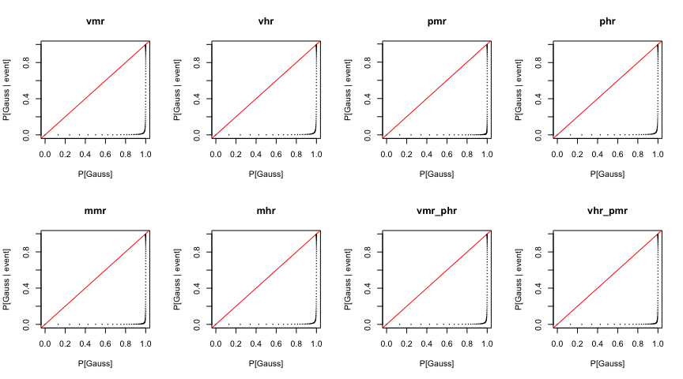

Use $1 - \text{p-value}$ from Lilliefors test as prior probability that the distribution is Gaussian.  
$x_{\text{obs}} = \min(x)$ and $P[\text{Event}\ |\ \text{Gaussian}] = P_{\text{Gauss}}[X \leq x_{\text{min}}]$:

|  | vmr | vhr | pmr | phr | mmr | mhr | vmr_phr | vhr_pmr |
| --- | --- | --- | --- | --- | --- | --- | --- | --- |
| Lillie p-val | 0.000 | 0.00 | 0.000 | 0.00 | 0.000 | 0.001 | 0.001 | 0.000 |
| Prior prob | 1.000 | 1.00 | 1.000 | 1.00 | 1.000 | 0.999 | 0.999 | 1.000 |
| P[Gauss \| Event] | 0.838 | 0.82 | 0.768 | 0.69 | 0.815 | 0.486 | 0.418 | 0.965 |

Use $1 - \text{p-value}$ from Lilliefors test as prior probability that the distribution is Gaussian.  
$x_{\text{obs}} = \max(x)$ and $P[\text{Event}\ |\ \text{Gaussian}] = P_{\text{Gauss}}[X \geq x_{\text{max}}]$:

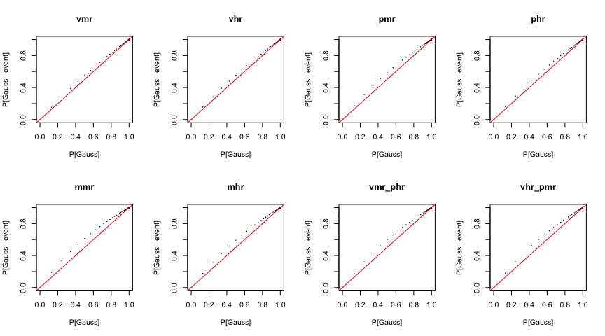

|  | vmr | vhr | pmr | phr | mmr | mhr | vmr_phr | vhr_pmr |
| --- | --- | --- | --- | --- | --- | --- | --- | --- |
| Lillie p-val | 0 | 0 | 0 | 0 | 0 | 0.001 | 0.001 | 0 |
| Prior prob | 1 | 1 | 1 | 1 | 1 | 0.999 | 0.999 | 1 |
| P[Gauss \| Event] | 1 | 1 | 1 | 1 | 1 | 1.000 | 1.000 | 1 |

# Velliv medium risk (vmr), June 2012 - April 2024

## QQ Plot

Skewed $t$-distribution (sstd):

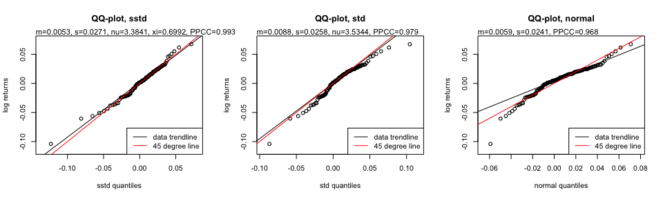

## Data vs fit

Let’s plot the fit and the observed returns together.

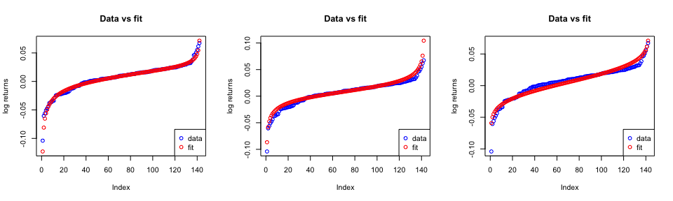

## Estimated distribution

Now lets look at the CDF of the estimated distribution for each 0.1% increment between 0.5% and 99.5% for the estimated distribution:

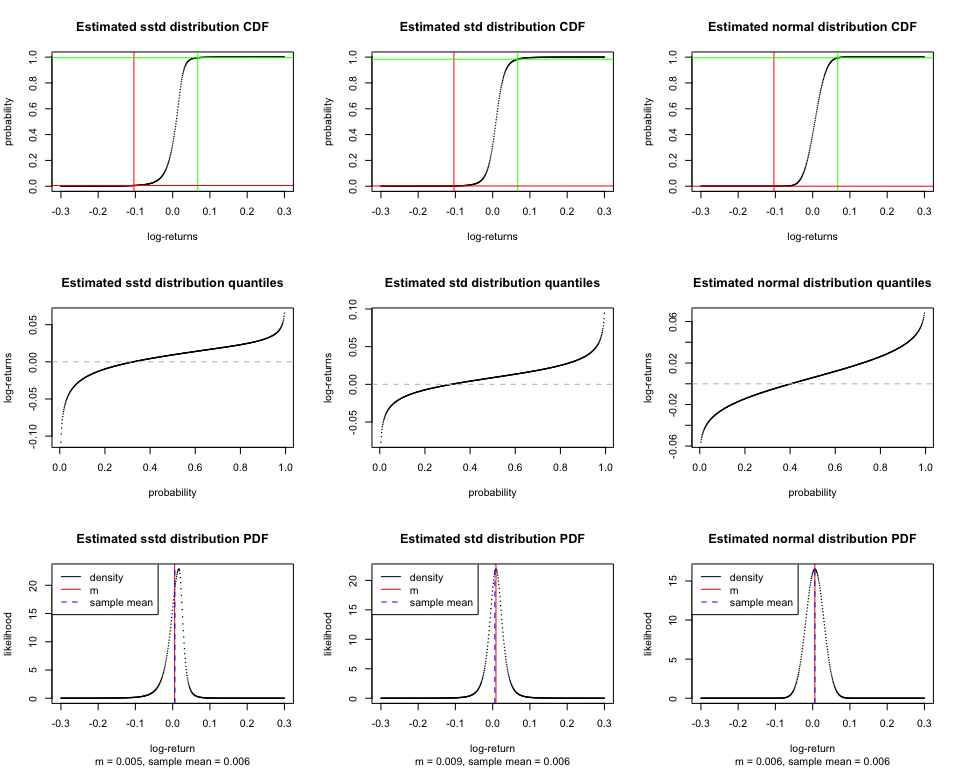

## Monte Carlo

Sorted portfolio index values for last period of all runs

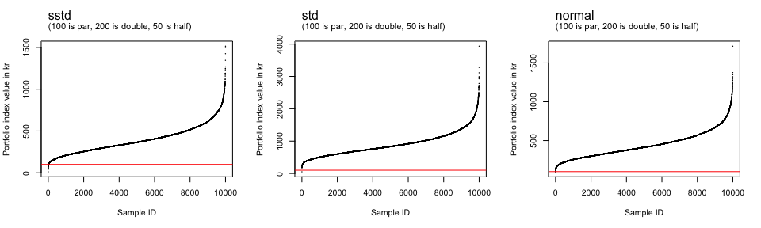

## Convergence

### Max vs sum

Max-vs-sum plots for the first four moments – a ratio that doesn’t fall toward zero flags that moment as possibly non-existent (see “Max-sum plots” in the comparison report for what this diagnostic tests). Panels by fitted distribution:

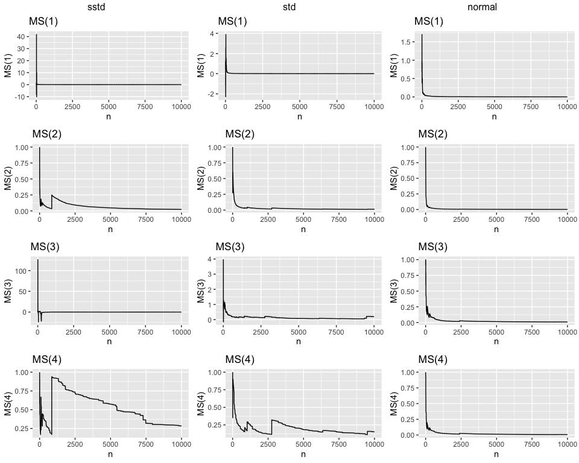

### MC

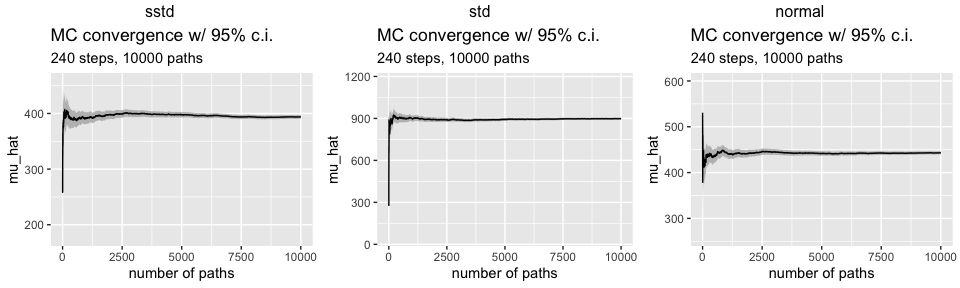

### IS

Skewed $t$-distribution with a normal proposal distribution.

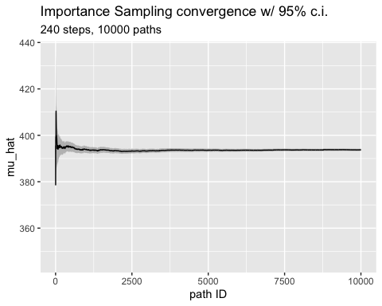

Parameters

```
## [1] 1.4575522 0.4135162
```

Objective function plots

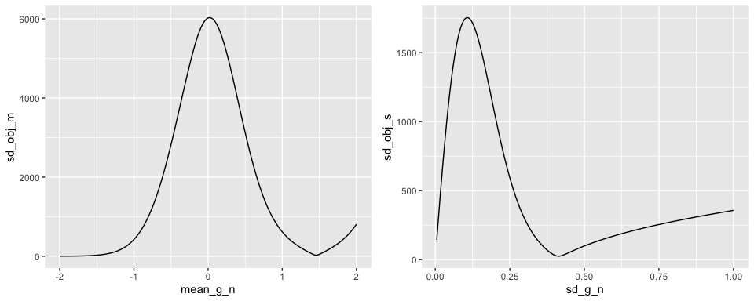

# Velliv high risk (vhr), June 2012 - April 2024

## QQ Plot

Skewed $t$-distribution (sstd):

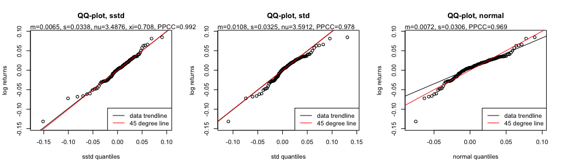

## Data vs fit

Let’s plot the fit and the observed returns together.

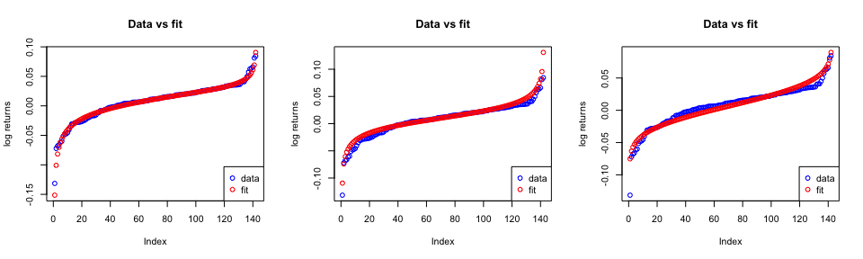

## Estimated distribution

Now lets look at the CDF of the estimated distribution for each 0.1% increment between 0.5% and 99.5% for the estimated distribution:

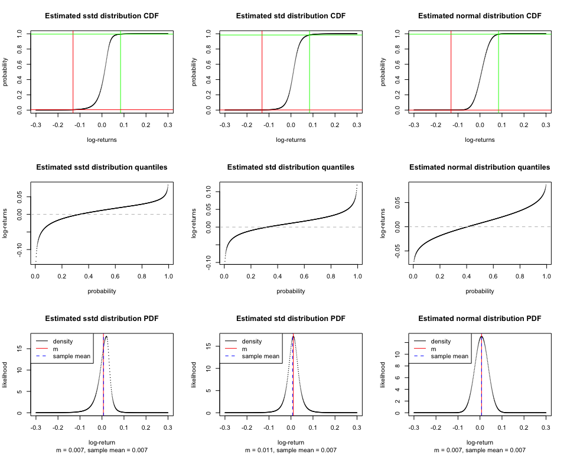

## Monte Carlo

Sorted portfolio index values for last period of all runs

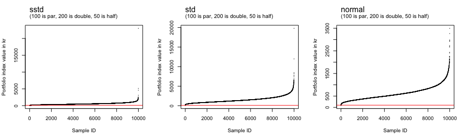